# Titanic Journal

[Fran Pérez](https://es.linkedin.com/in/franjperez)

2016-05-18

## Introduction

There are several posts in the Internet which describe how to squeeze and process data coming from the Kaggle’s Titanic datasets. Basically, I based my research on [Exploring the Titanic Dataset](https://www.kaggle.com/mrisdal/titanic/exploring-survival-on-the-titanic/notebook) and [Titanic: Getting Started with R](http://trevorstephens.com/post/72916401642/titanic-getting-started-with-r), both of them are terrific examples about how to address several problems in these datasets. I humbly extend their research, adding personal names to the data, in order to give another perspective which is not merely “statistic”, pretending to merge data and social views. I will try to turn this essay in my first attempt on [data journalism](http://datajournalismhandbook.org/1.0/en/introduction_0.html) and [reproducible research](https://cran.r-project.org/web/views/ReproducibleResearch.html). Alongside this essay, I will publish another short posts about reproducible research patterns on R. My aim is to prove that reproducible research is good tool for any developer.

## Feature engineering

Loading packages used for feature engineering

```r
library(plyr) # dataframe manipulation
library(dplyr) # dataframe manipulation
library(readr) # csv file read / write
library(ggplot2) # data plots
library(reshape2) # dataframe manipulation
library(stringr) # string handling
library(mice) # regression
library(knitr)
```

I use `read_csv` function in order to load data from training and test files into a couple of dataframes. After loading, we add a column named `Survived` to the test dataframe (initialized to NA), which will be used as a placeholder (training dataset already has got `Survived` as column). Once the `Survived` column is present in both dataframes, they can be combined in a single dataframe named `combi`. From now on, we will use variable names starting by `rows.*` for representing logical/int vectors, and they will be used as row dataframe filters. For instance, `rows.train` will represent rows from combi dataframe which belong to the original training dataframe.

```r
csv.folder <- "../../titanic/"
#kaggle folder
#csv.folder <- "../input/"
train <- read_csv(file = paste0(csv.folder,"train.csv"))
test <- read_csv(file = paste0(csv.folder,"test.csv"))

combi <- train %>% bind_rows(test %>% mutate(Survived = NA))
# copy original data
combi.original <- combi
rows.train <- !is.na(combi$Survived)
```

The combined dataset contains 1309 rows, and 12 variables. Kaggle give us some [basic information](https://www.kaggle.com/c/titanic/data) about the meaning of the variables:

| Column | Description |
| --- | --- |
| PassengerId | passenger id (no useful information) |
| Survived | survival label: 1 (survived), 0 (died) |
| Pclass | ticket’s class (passenger’s socio-economic status) |
| Name | Passenger’s name |
| Sex | Passenger’s sex |
| Age | Passenger’s age |
| SibSp | Number of siblings / spouses aboard |
| Parch | Number of parents / children aboard |
| Ticket | Ticket identifier |
| Fare | Ticket’s price (pounds) |
| Cabin | Passenger’s cabin |
| Embarked | Port of embarkation |

### Pclass and Sex

Basically, turn them into factors and that’s it

```r
combi$Pclass <- factor(combi$Pclass)
combi$Sex <- factor(combi$Sex)
```

### Title

I will create a new predictor, based on the value of the `Name` column, which always contain the person’s honorific title. Less frequent titles will be grouped in a new bin (title) called Noble.

For internal reminder, and for other non-english speakers, I attached english honorific title *cheatsheet*:

**master**

(children) male

**mr**

(un/married) male

**miss**

unmarried female

**mrs**

married female

Another honorific titles in the tripulation list came from another languages:

**Dona**

spanish title which is equivalent to Mrs (correct form is “Doña”)  
[Oliva y Ocana, Dona. Fermina](http://www.encyclopedia-titanica.org/titanic-survivor/fermina-oliva-y-ocana.html)

**Don**

spanish title which is equivalent to Mr  
[Uruchurtu, Don. Manuel](http://www.encyclopedia-titanica.org/titanic-victim/manuel-uruchurtu.html)

**Mme / Mlle**

french title which is equivalent to Miss  
[Aubart, Mme. Leontine Pauline](http://www.encyclopedia-titanica.org/titanic-survivor/leontine-pauline-aubart.html) and [Mayne, Mlle. Berthe Antonine](http://www.encyclopedia-titanica.org/titanic-survivor/bertha-mayne.html)

**Jonkheer**

dutch title equivalent to Mr  
[Reuchlin, Jonkheer. John George](http://www.encyclopedia-titanica.org/titanic-victim/johan-george-reuchlin.html)

```r
# title regex and trimming
combi$Title <- sapply(combi$Name, FUN = function(x) {
    strsplit(x, split = '[,.]')[[1]][2]
})
combi$Title <- sub(' ', '', combi$Title)

# raw titles
table(combi$Title)
```

```
##
##         Capt          Col          Don         Dona           Dr     Jonkheer         Lady        Major       Master
##            1            4            1            1            8            1            1            2           61
##         Miss         Mlle          Mme           Mr          Mrs           Ms          Rev          Sir the Countess
##          260            2            1          757          197            2            8            1            1
```

```r
# combine titles
combi$Title[combi$Title %in% c('Capt', 'Col', "Dr", "Major", "Rev", "Sir")] <- 'Noble'
combi$Title[combi$Title %in% c('Dona', 'Ms', 'the Countess','Lady')] <- 'Mrs'
combi$Title[combi$Title %in% c('Mme', 'Mlle')] <- 'Miss'
combi$Title[combi$Title %in% c("Jonkheer","Don")] <- 'Mr'

# convert to factor
combi$Title <- factor(combi$Title)
```

safe check

I made an special title category combining “Capt”, “Col”, “Dr”, “Major”, “Rev”, “Sir” as these titles are bound to some “attitudes”/jobs which may influence passenger’s fate.

```r
kable(combi %>% filter (Title == "Noble") %>% select (Name, Pclass, Age, Survived) %>% arrange (Survived, Pclass))
```

| Name | Pclass | Age | Survived |
| --- | --- | --- | --- |
| Minahan, Dr. William Edward | 1 | 44 | 0 |
| Butt, Major. Archibald Willingham | 1 | 45 | 0 |
| Weir, Col. John | 1 | 60 | 0 |
| Crosby, Capt. Edward Gifford | 1 | 70 | 0 |
| Brewe, Dr. Arthur Jackson | 1 | NA | 0 |
| Byles, Rev. Thomas Roussel Davids | 2 | 42 | 0 |
| Bateman, Rev. Robert James | 2 | 51 | 0 |
| Carter, Rev. Ernest Courtenay | 2 | 54 | 0 |
| Moraweck, Dr. Ernest | 2 | 54 | 0 |
| Pain, Dr. Alfred | 2 | 23 | 0 |
| Kirkland, Rev. Charles Leonard | 2 | 57 | 0 |
| Harper, Rev. John | 2 | 28 | 0 |
| Montvila, Rev. Juozas | 2 | 27 | 0 |
| Peuchen, Major. Arthur Godfrey | 1 | 52 | 1 |
| Duff Gordon, Sir. Cosmo Edmund (“Mr Morgan”) | 1 | 49 | 1 |
| Stahelin-Maeglin, Dr. Max | 1 | 32 | 1 |
| Simonius-Blumer, Col. Oberst Alfons | 1 | 56 | 1 |
| Frauenthal, Dr. Henry William | 1 | 50 | 1 |
| Leader, Dr. Alice (Farnham) | 1 | 49 | 1 |
| Gracie, Col. Archibald IV | 1 | 53 | NA |
| Astor, Col. John Jacob | 1 | 47 | NA |
| Dodge, Dr. Washington | 1 | 53 | NA |
| Lahtinen, Rev. William | 2 | 30 | NA |
| Peruschitz, Rev. Joseph Maria | 2 | 41 | NA |

Then, I review `Sex` and `Age` distribution by `Title`, looking for interesting facts

```r
table(combi$Sex, combi$Title, dnn = c("Sex", "Title"))
```

```
##         Title
## Sex      Master Miss  Mr Mrs Noble
##   female      0  263   0 202     1
##   male       61    0 759   0    23
```

```r
tapply(combi$Age, combi$Title, summary)
```

```
## $Master
##    Min. 1st Qu.  Median    Mean 3rd Qu.    Max.    NA's
##   0.330   2.000   4.000   5.483   9.000  14.500       8
##
## $Miss
##    Min. 1st Qu.  Median    Mean 3rd Qu.    Max.    NA's
##    0.17   15.00   22.00   21.81   30.00   63.00      50
##
## $Mr
##    Min. 1st Qu.  Median    Mean 3rd Qu.    Max.    NA's
##   11.00   23.00   29.00   32.28   39.00   80.00     176
##
## $Mrs
##    Min. 1st Qu.  Median    Mean 3rd Qu.    Max.    NA's
##   14.00   27.00   35.50   36.99   46.50   76.00      28
##
## $Noble
##    Min. 1st Qu.  Median    Mean 3rd Qu.    Max.    NA's
##   23.00   41.50   49.00   46.39   53.50   70.00       1
```

**interesting facts**

- Noble title only includes one woman ([Leader, Dr. Alice](http://www.encyclopedia-titanica.org/titanic-survivor/alice-leader.html)), rest of title categories are *sex orthogonal* (either female / male). In this case, Alice Leader could be easily moved to the “Mrs” category
- Master’s max age is 14.5, while other titles have a wide array of ages

### Family size

Create a new predictor based on the sum of `Parch` and `SibSp`. Maybe the survival ratio shows some correlation with the size of the family (does the family sink or swim together?)

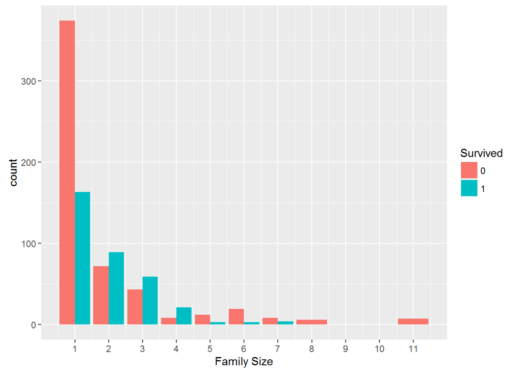

```r
combi$Family.Size <- combi$SibSp + combi$Parch + 1

ggplot(combi[rows.train,], aes(x = Family.Size, fill = factor(Survived))) +
  geom_bar(stat='count', position='dodge') +
  scale_x_continuous(breaks=seq(max(combi$Family.Size))) +
  labs(x = 'Family Size', fill='Survived')
```

safe check

I was surprised by single person’s numbers, as I thought this condition would be beneficial for them. Is there any other cause for these numbers? Let’s check, for example, how many singles are per class:

```r
table(combi$Pclass, combi$Family.Size, dnn=c("Class","Family Size"))
```

```
##      Family Size
## Class   1   2   3   4   5   6   7   8  11
##     1 160 104  39   9   5   6   0   0   0
##     2 158  52  45  20   1   1   0   0   0
##     3 472  79  75  14  16  18  16   8  11
```

Most of singles were traveling in third class (same as most of families with more than 4 members). Drilling down on these figures:

```r
table(combi$Pclass[rows.train], combi$Family.Size[rows.train], combi$Survived[rows.train], dnn=c("Class", "Family Size", "Survived"))
```

```
## , , Survived = 0
##
##      Family Size
## Class   1   2   3   4   5   6   7   8  11
##     1  51  19   6   2   0   2   0   0   0
##     2  68  16  10   3   0   0   0   0   0
##     3 255  37  27   3  12  17   8   6   7
##
## , , Survived = 1
##
##      Family Size
## Class   1   2   3   4   5   6   7   8  11
##     1  58  51  18   5   2   2   0   0   0
##     2  36  18  21  10   1   1   0   0   0
##     3  69  20  20   6   0   0   4   0   0
```

Singles in first class were luckier than singles in second and third class. Most first class passengers were located in upper decks and had access to exclusive areas; this is one of the numerous reasons their fate ratio was better than passengers in other classes.

**interesting facts**

Small families seems to be favored against larger families and singles, but this need to be checked against other features (like Pclass, Title or Deck).

### Embarked

```r
(.lastVal <- combi[is.na(combi$Embarked),c("Name", "Pclass", "Ticket", "Fare")])
```

```
## Source: local data frame [2 x 4]
##
##                                        Name Pclass Ticket  Fare
##                                       (chr) (fctr)  (chr) (dbl)
## 1                       Icard, Miss. Amelie      1 113572    80
## 2 Stone, Mrs. George Nelson (Martha Evelyn)      1 113572    80
```

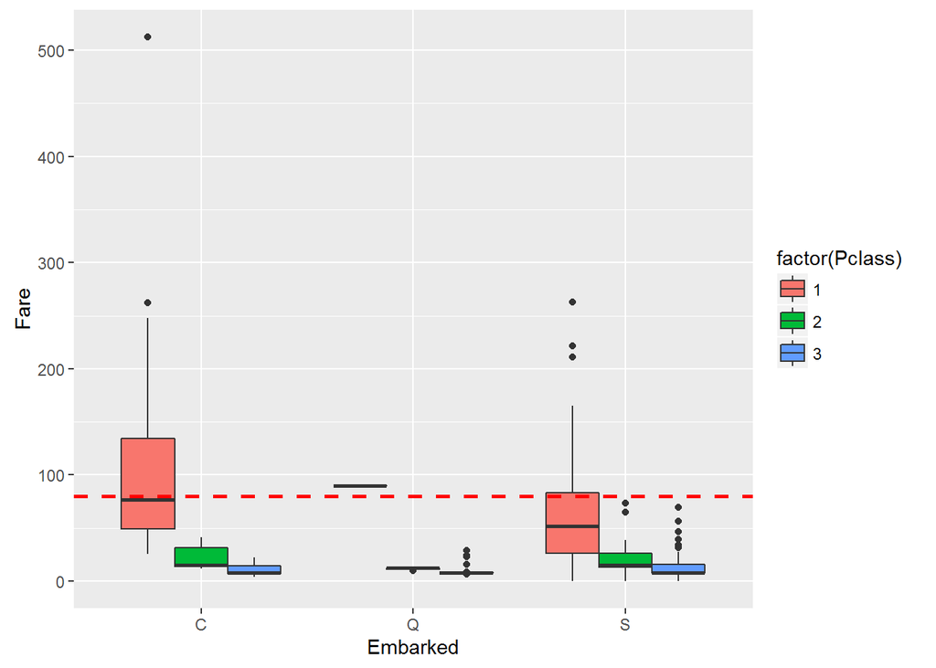

```r
ggplot(combi, aes(x = Embarked, y = Fare, fill = factor(Pclass))) +
  geom_boxplot() +
  geom_hline(aes(yintercept=80),
    colour='red', linetype='dashed', lwd=1) +
  scale_y_continuous()
```

The price paid by those 2 tickets was 80, and this price fits closer the median of the Cherbourg port (`"C"` value) .

```r
rows.fix.embarked <- is.na(combi$Embarked)
combi$Embarked[rows.fix.embarked] = "C"
# Convert to factor
combi$Embarked <- factor(combi$Embarked)
```

**interesting facts**

Fixing those two missing values may seem not relevant for the size of the whole sample, but some machine learning algorithms require complete data sets.

### Age

`Age` column contains many missing values.

```r
summary(combi$Age)
```

```
##    Min. 1st Qu.  Median    Mean 3rd Qu.    Max.    NA's
##    0.17   21.00   28.00   29.88   39.00   80.00     263
```

```r
rows.fix.age <- is.na(combi$Age)
# % missing Age values
prop.table(table(rows.fix.age))
```

```
## rows.fix.age
##     FALSE      TRUE
## 0.7990833 0.2009167
```

After testing several imputation methods, MICE seems to fix the issues smoothly.

```r
# so much in order to supress output from mice command
nn <- capture.output (model.age <- complete(mice(combi[,c("Pclass","Sex","SibSp","Parch","Embarked","Title","Family.Size","Age","Fare")], method="rf")) , file = NULL)
```

safe check

Let’s review new age distribution density … did it change old age distribution?

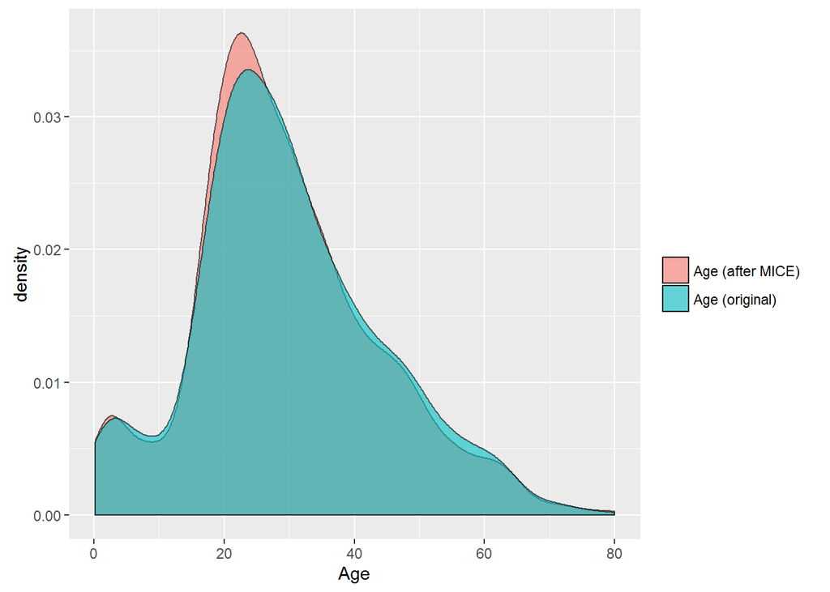

```r
age.type <- combi[!rows.fix.age,] %>%
    mutate (AgeType = "Age (original)") %>%
    select (Age, AgeType) %>%
    bind_rows(model.age %>%
                mutate (AgeType="Age (after MICE)") %>%
                select (Age, AgeType))
ggplot(age.type, aes(x = Age)) +
    geom_density(aes(fill = factor(AgeType)), alpha = 0.6) +
    #scale_fill_manual(values = c(alpha("green", 0.25), alpha("blue", 0.4))) +
    labs(x = 'Age', fill = '')
```

```r
rm (age.type)
```

Density curves show that `Age` frequencies didn’t change after imputation, so new age data can be considered “safe”.

```r
combi$Age <- model.age$Age
```

A new predictor based on the `Age` could be useful, because children and mothers were supposed to be first passengers to be transferred to lifeboats. In order to understand who was considered child by the time and place, we found this mention in [Demographics of the TITANIC Passengers](http://www.icyousee.org/titanic.html) :

> “Who was a child was relative depending on class. For example, 14 year old Lucile Carter in First Class was considered a child, but a 14 year old Annie McGowan in Steerage was considered to be an adult.”

```r
combi$Age.IsChild <- (combi$Age < 16 & (combi$Pclass == 1 | combi$Pclass==2)) | (combi$Age < 14 & combi$Pclass == 3)
combi$Age.IsMother <- !combi$Age.IsChild & combi$Parch > 0 & combi$Title == "Mrs"
```

safe check

I know, I know .. we don’t need to be so precise, but it makes me feel better. Then, review survival ratios for `Age.IsChild` and `Age.IsMother` predictors by class

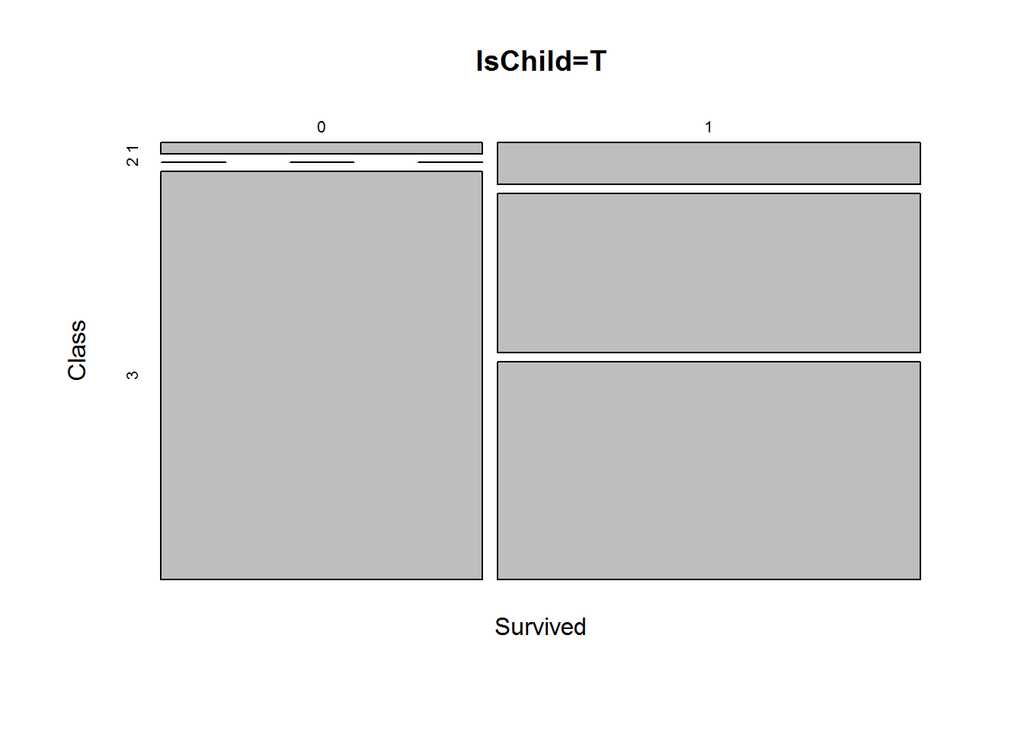

```r
rows.train.and.child <- rows.train & combi$Age.IsChild
plot(table(combi$Survived[rows.train.and.child], combi$Pclass[rows.train.and.child], dnn=c("Survived","Class")), main="IsChild=T")
```

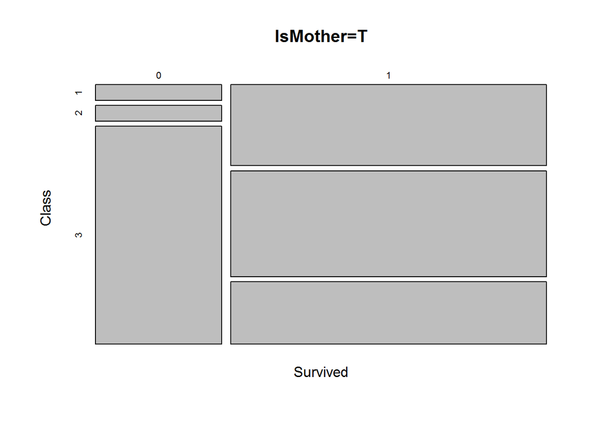

```r
rows.train.and.mother <- rows.train & combi$Age.IsMother
plot(table(combi$Survived[rows.train.and.mother], combi$Pclass[rows.train.and.mother], dnn=c("Survived","Class")), main="IsMother=T")
```

**interesting facts**

Luck favored passengers in first and second class, regardless of whether was child or mother. But the percentage of saved mothers is higher than children.

### Fare

Let’s inspect `Fare` feature:

```r
summary(combi$Fare)
```

```
##    Min. 1st Qu.  Median    Mean 3rd Qu.    Max.    NA's
##   0.000   7.896  14.450  33.300  31.280 512.300       1
```

There are two interesting cases:

1. a single passenger with missing ticket price (NA)
2. passengers which didn’t pay a penny because they were *VIP* (like [Mr Joseph Bruce Ismay](http://www.encyclopedia-titanica.org/titanic-survivor/j-bruce-ismay.html)) or patronized ([Mr Jonkheer Johan George Reuchlin](http://www.encyclopedia-titanica.org/titanic-victim/johan-george-reuchlin.html))

```r
rows.fare.na <-  is.na(combi$Fare)
rows.fare.zero <- combi$Fare == 0
kable(combi %>%
    filter (rows.fare.na | rows.fare.zero) %>%
    select (Name, Pclass, Ticket, Fare, Age, Survived) %>%
    arrange (Pclass, Survived, Name))
```

| Name | Pclass | Ticket | Fare | Age | Survived |
| --- | --- | --- | --- | --- | --- |
| Andrews, Mr. Thomas Jr | 1 | 112050 | 0 | 39.0 | 0 |
| Fry, Mr. Richard | 1 | 112058 | 0 | 39.0 | 0 |
| Harrison, Mr. William | 1 | 112059 | 0 | 40.0 | 0 |
| Parr, Mr. William Henry Marsh | 1 | 112052 | 0 | 28.0 | 0 |
| Reuchlin, Jonkheer. John George | 1 | 19972 | 0 | 38.0 | 0 |
| Chisholm, Mr. Roderick Robert Crispin | 1 | 112051 | 0 | 31.0 | NA |
| Ismay, Mr. Joseph Bruce | 1 | 112058 | 0 | 49.0 | NA |
| Campbell, Mr. William | 2 | 239853 | 0 | 34.0 | 0 |
| Cunningham, Mr. Alfred Fleming | 2 | 239853 | 0 | 28.0 | 0 |
| Frost, Mr. Anthony Wood “Archie” | 2 | 239854 | 0 | 37.0 | 0 |
| Knight, Mr. Robert J | 2 | 239855 | 0 | 35.0 | 0 |
| Parkes, Mr. Francis “Frank” | 2 | 239853 | 0 | 30.0 | 0 |
| Watson, Mr. Ennis Hastings | 2 | 239856 | 0 | 25.0 | 0 |
| Johnson, Mr. Alfred | 3 | LINE | 0 | 49.0 | 0 |
| Johnson, Mr. William Cahoone Jr | 3 | LINE | 0 | 19.0 | 0 |
| Leonard, Mr. Lionel | 3 | LINE | 0 | 36.0 | 0 |
| Tornquist, Mr. William Henry | 3 | LINE | 0 | 25.0 | 1 |
| Storey, Mr. Thomas | 3 | 3701 | NA | 60.5 | NA |

Digging deeper on the fare cases, the single passenger with missing fare is [Mr Thomas Storey](http://www.encyclopedia-titanica.org/titanic-victim/thomas-storey.html), who was working for the American Line as a seaman. So I’d say that this passenger didn’t pay for its ticket. Against my personal believe, most of these *VIP* passengers did not survive (maybe because they view themselves as crew members, who most of them died as well) Anyway, I set a dummy variable `Fare.IsZero` to flag these passengers.

```r
combi$Fare[rows.fare.na] <- 0
rows.fare.zero <- rows.fare.na | rows.fare.zero
combi$Fare.IsZero <- rows.fare.zero
```

I create another feature as the ratio between fare paid and family size.

```r
combi$Fare.PerPerson <- combi$Fare / combi$Family.Size
```

`Fare` has some outliers. There are several ways to normalize cases like this one, I will use one of the common ones: log value.

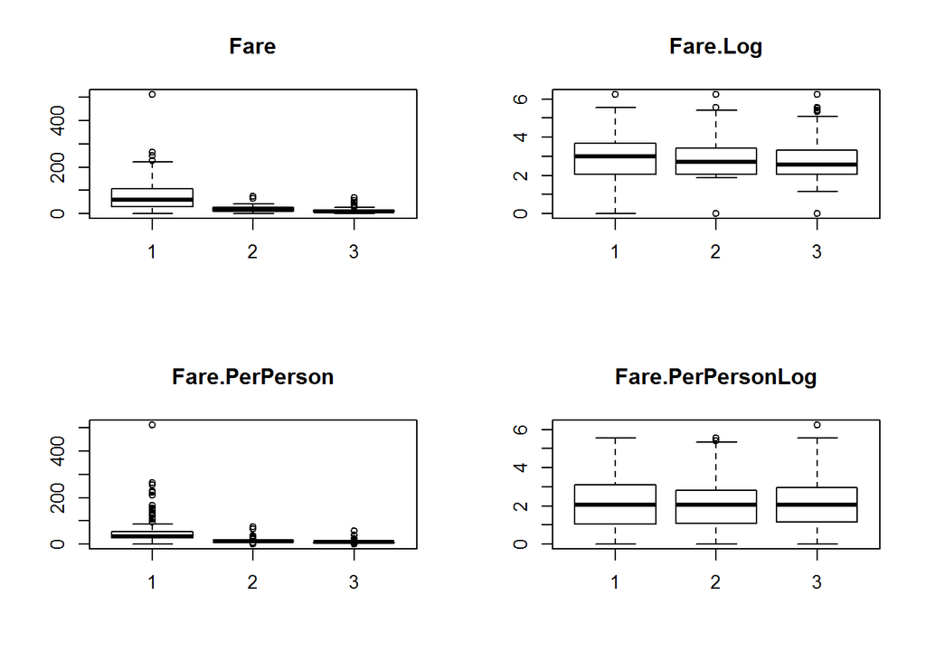

```r
combi$Fare.Log[ combi$Fare.IsZero] <- 0
combi$Fare.Log[!combi$Fare.IsZero] <- log(combi$Fare)
combi$Fare.PerPersonLog <- combi$Fare.Log / combi$Family.Size
par(mfrow=c(2,2))
boxplot(Fare ~ Pclass, combi, main = "Fare")
boxplot(Fare.Log ~ Pclass, combi, main = "Fare.Log")
boxplot(Fare.PerPerson ~ Pclass, combi, main = "Fare.PerPerson")
boxplot(Fare.PerPersonLog ~ Pclass, combi, main = "Fare.PerPersonLog")
```

**interesting facts**

Ticket fare mainly depends on ticket class and number of passengers travelling on the same ticket. But also, children paid less for the ticket, there were family tickets to make the travel affordable to all kind of families. Finally, the ticket also cover the trip from the origin city to the port.

### Ticket Name

[figure not shown]

`Ticket` column has no missing values. Let’s check ticket data values, looking for *visual* data patterns:

```r
# missing values in Ticket column should be zero
sum(is.na(combi$Ticket))
```

```
## [1] 0
```

```r
# tickets sample
sample(unique(combi$Ticket), 30)
```

```
##  [1] "383123"            "STON/O 2. 3101286" "349240"            "233478"            "113801"
##  [6] "S.O.C. 14879"      "347064"            "STON/O 2. 3101268" "S.C./PARIS 2079"   "113509"
## [11] "330980"            "17421"             "S.P. 3464"         "SOTON/OQ 392082"   "349210"
## [16] "2621"              "A/4 48871"         "W./C. 14263"       "364856"            "347073"
## [21] "219533"            "228414"            "349250"            "W./C. 6609"        "349209"
## [26] "C.A. 2673"         "363294"            "S.W./PP 752"       "A/5. 10482"        "A/5 3540"
```

There is a common pattern used in the `Ticket` column `name + space + code`, although there are some tickets with only *code* (numeric part). Is there any meaning behind this schema?

I will try to bring some light into the issue. First, I will create a new `Ticket.Name` column, storing the *name* part of the ticket

```r
ticketNames <- sapply(combi$Ticket, FUN = function(ticket) {
    names <- strsplit(ticket, " ")[[1]]
    ifelse(length(names) > 1, names[1], NA)
})
sample(unique(ticketNames), 30)
```

```
##  [1] "S.O.C."     "A/5"        "F.C."       "SC/A.3"     "A/5."       "SC/PARIS"   "S.C./PARIS" "A4."
##  [9] "CA"         "C"          "SC/A4"      "SO/C"       "F.C.C."     "S.O./P.P."  "SC"         "S.W./PP"
## [17] "C.A."       "SC/Paris"   "STON/O"     "S.C./A.4."  NA           "S.O.P."     "SOTON/O2"   "SC/AH"
## [25] "C.A./SOTON" "W./C."      "SW/PP"      "PC"         "AQ/3."      "STON/OQ."
```

safe check

Is there any correlation between ticket names and any other feature? Chi-square test is not really a reliable test, but it might help us …

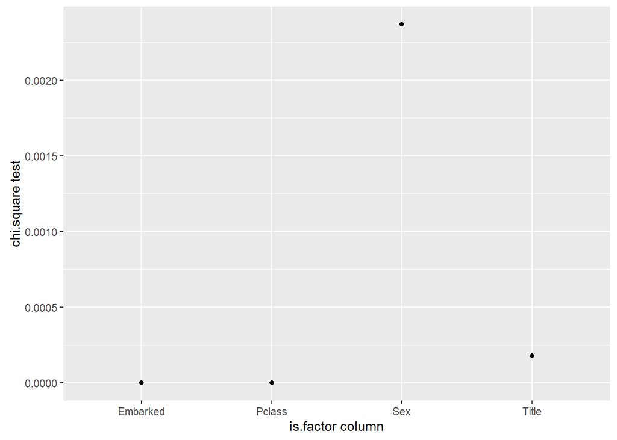

```r
combi.columns.isfactor <- names(combi)[sapply(combi, is.factor)]
ticketNames.chisq <- apply(combi[,combi.columns.isfactor], 2, function (x) {chisq.test(ticketNames,x)$p.value})
ggplot() + geom_point(aes(x = names(ticketNames.chisq), y = ticketNames.chisq)) + xlab("is.factor column") + ylab ("chi.square test")
```

Chi-square test of categorical features show some correlation between ticket name and class and embarked classes.

Let’s prove chi-square test making a *visual* correlation, using a combined table to help us match patterns

```r
combi$Ticket.Name <- ticketNames
name.by.class <- table(combi$Ticket.Name, combi$Pclass)
name.by.port <- table(combi$Ticket.Name, combi$Embarked)
name.by.class.port <- as.data.frame.matrix(name.by.class) %>% bind_cols(as.data.frame.matrix(name.by.port))
name.by.class.port$name <- row.names(name.by.class)
print(name.by.class.port, n=50)
```

```
## Source: local data frame [49 x 7]
##
##        1     2     3     C     Q     S       name
##    (int) (int) (int) (int) (int) (int)      (chr)
## 1      0     0     1     0     0     1         A.
## 2      0     0     3     0     0     3      A./5.
## 3      0     0     3     0     0     3       A.5.
## 4      0     0     6     0     0     6        A/4
## 5      0     0     3     0     0     3       A/4.
## 6      0     0    12     0     0    12        A/5
## 7      0     0    10     0     1     9       A/5.
## 8      0     0     1     0     0     1        A/S
## 9      0     0     1     0     0     1        A4.
## 10     0     0     1     0     1     0      AQ/3.
## 11     0     0     1     0     1     0       AQ/4
```

[output cut: 38 more lines]

Previous table brings to light 4 different patterns:

```r
name.by.class.port[name.by.class.port$name %in% c("W./C.","SC/AH","C.A.","A/4"),]
```

```
## Source: local data frame [4 x 7]
##
##       1     2     3     C     Q     S  name
##   (int) (int) (int) (int) (int) (int) (chr)
## 1     0     0     6     0     0     6   A/4
## 2     0    31    15     1     0    45  C.A.
## 3     0     5     0     1     0     4 SC/AH
## 4     0     4    10     0     0    14 W./C.
```

A new column can be created combining *synonym* ticket names (for example, I consider `C.A.` and `CA` *synonyms*) crossed by class and embarkation port; this new column will be set to `UNK` for passengers with no ticket name. This new classification is subject to my bias, and I’d like to find a more robust method to make this classification, but for now this should work.

```r
combi$Ticket.Name[combi$Ticket.Name %in% c("A.", "A/4", "A/5", "S.C./A.4.", "A./5.", "A.5.", "A/5", "A/5.", "A/S", "A4.", "SC/A4", "A/4.")] <- "A3"
combi$Ticket.Name[combi$Ticket.Name %in% c("AQ/3.", "AQ/4")] <- "AQ3"
combi$Ticket.Name[combi$Ticket.Name %in% c("C")] <- "CS3"
combi$Ticket.Name[combi$Ticket.Name %in% c("C.A./SOTON")] <- "CS2"
combi$Ticket.Name[combi$Ticket.Name %in% c("CA", "C.A.") & combi$Pclass == 2] <- "CA2"
combi$Ticket.Name[combi$Ticket.Name %in% c("CA", "C.A.") & combi$Pclass == 3] <- "SO3"
combi$Ticket.Name[combi$Ticket.Name %in% c("F.C.")] <- "FC1"
combi$Ticket.Name[combi$Ticket.Name %in% c("F.C.C.")] <- "FC2"
combi$Ticket.Name[combi$Ticket.Name %in% c("Fa")] <- "FA3"
combi$Ticket.Name[combi$Ticket.Name %in% c("LP", "PP")] <- "PP3"
combi$Ticket.Name[combi$Ticket.Name %in% c("P/PP")] <- "PP2"
combi$Ticket.Name[combi$Ticket.Name %in% c("PC")] <- "PP1"
combi$Ticket.Name[combi$Ticket.Name %in% c("S.C./PARIS", "SC/Paris", "SC", "SC/A.3", "SC/AH", "SC/PARIS", "SCO/W", "SO/C", "S.O.C.")] <- "SC2"
combi$Ticket.Name[combi$Ticket.Name %in% c("S.O.P.", "S.O./P.P.") & combi$Pclass == 2] <- "SP2"
combi$Ticket.Name[combi$Ticket.Name %in% c("S.O./P.P.", "S.P.") & combi$Pclass == 3] <- "SP3"
combi$Ticket.Name[combi$Ticket.Name %in% c("SOTON/O2", "SOTON/OQ", "SOTON/O.Q.", "CA.")] <- "SO3"
combi$Ticket.Name[combi$Ticket.Name %in% c("STON/O", "STON/O2.", "STON/OQ.")] <- "ST3"
combi$Ticket.Name[combi$Ticket.Name %in% c("W./C.","W/C") & combi$Pclass == 2] <- "WC2"
combi$Ticket.Name[combi$Ticket.Name %in% c("W./C.") & combi$Pclass == 3] <- "WC3"
combi$Ticket.Name[combi$Ticket.Name %in% c("WE/P", "W.E.P.")] <- "WP1"
combi$Ticket.Name[combi$Ticket.Name %in% c("S.W./PP", "SW/PP")] <- "SW2"

rows.fix.ticket.name <- is.na(combi$Ticket.Name)
combi$Ticket.Name[rows.fix.ticket.name] <- "UNK"
```

`Ticket.Name` has 21 diferent values. Some algorithms take advantage of smaller groups, so I will build a new classification, combining in the same category low frequency ticket names, and I will name this new column as `Ticket.NameSimple` .

```r
tabTicketName <- table(combi$Ticket.Name)
ticketNameUnder10 <- row.names(tabTicketName[tabTicketName <= 10])
combi$Ticket.NameSimple <- combi$Ticket.Name
combi$Ticket.NameSimple[combi$Ticket.NameSimple %in% ticketNameUnder10] <- "SMALL"
rm(ticketNameUnder10, tabTicketName)
```

The lower frequency threshold is set to 10, and the name of the new category is `SMALL`; the new column has 8 different values.

Finally, turn (both) ticket name categories into factors

```r
combi$Ticket.Name <- factor(combi$Ticket.Name)
combi$Ticket.NameSimple <- factor(combi$Ticket.NameSimple)
```

safe check

Let’s check if still exists some correlation between new ticket name column and class and boarding port

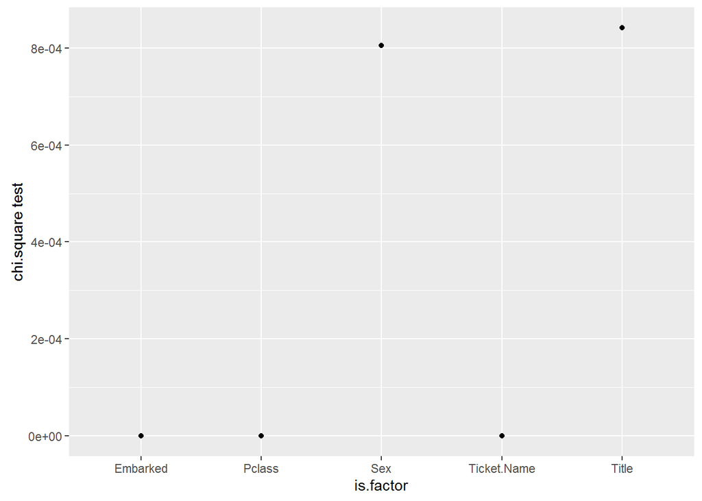

```r
ticketNames.chisq <- apply(combi[,c(combi.columns.isfactor,"Ticket.Name")], 2, function (x) {chisq.test(combi$Ticket.NameSimple,x)$p.value})
ggplot() + geom_point(aes(x = names(ticketNames.chisq), y = ticketNames.chisq)) + xlab("is.factor") + ylab ("chi.square test")
```

As expected, `Ticket.Name` is correlated with `Embarked` and `Pclass` features.

```r
name.by.class <- table(combi$Ticket.Name, combi$Pclass)
name.by.port <- table(combi$Ticket.Name, combi$Embarked)
# combine both tables into a single dataframe
name.by.class.port <- as.data.frame.matrix(name.by.class) %>% bind_cols(as.data.frame.matrix(name.by.port))
name.by.class.port$name <- row.names(name.by.class)
print(name.by.class.port, n=50)
```

```
## Source: local data frame [21 x 7]
##
##        1     2     3     C     Q     S  name
##    (int) (int) (int) (int) (int) (int) (chr)
## 1      0     0    42     0     1    41    A3
## 2      0     0     2     0     2     0   AQ3
## 3      0    33     0     1     0    32   CA2
## 4      0     1     0     0     0     1   CS2
## 5      0     0     8     0     0     8   CS3
## 6      0     0     1     0     0     1   FA3
## 7      3     0     0     1     0     2   FC1
## 8      0     9     0     0     0     9   FC2
## 9     92     0     0    72     0    20   PP1
## 10     0     2     0     2     0     0   PP2
## 11     0     0     5     0     0     5   PP3
## 12     0    36     0    21     0    15   SC2
## 13     0     0    62     0     0    62   SO3
## 14     0     5     0     0     0     5   SP2
## 15     0     0     4     0     0     4   SP3
## 16     0     0    22     0     0    22   ST3
## 17     0     2     0     0     0     2   SW2
## 18   224   184   553   175   120   666   UNK
## 19     0     5     0     0     0     5   WC2
## 20     0     0    10     0     0    10   WC3
## 21     4     0     0     0     0     4   WP1
```

Reviewing last table, I wonder if passengers with the same ticket share same “areas” on the ship. Most essays confirm that survival fate was related to closeness to lifeboats or which side of ship the cabin was located. The physical location of the cabin could be important because most of the passengers were sleeping at their cabins by the time of the iceberg crash.

Let’s do a visual inspection between `Ticket` and `Cabin`, looking for patterns. My hypothesis is that passengers with the same ticket will be located at the same cabin, so let’s check if there are cases which defy former hyphotesis:

```r
.lastVal <- (print (combi %>% group_by(Pclass, Cabin) %>% summarise(count = n_distinct(Ticket)) %>% filter(count > 1 & !is.na(Cabin)) %>% arrange(Pclass, count), n = 40))
```

```
## Source: local data frame [16 x 3]
## Groups: Pclass [3]
##
##    Pclass       Cabin count
##    (fctr)       (chr) (int)
## 1       1 B51 B53 B55     2
## 2       1        C101     2
## 3       1        C106     2
## 4       1        C124     2
## 5       1         C52     2
## 6       1         C78     2
## 7       1         D17     2
## 8       1         E24     2
## 9       1         E25     2
## 10      2          F2     2
## 11      2        E101     3
## 12      2           D     4
## 13      2         F33     4
## 14      3       F G63     2
## 15      3       F G73     2
## 16      3          G6     2
```

Yes, there are few exceptions. Let’s go deeper and inspect (for example) cabin F33 in order to check the *history* behind:

```r
combi %>% filter(Cabin == "F33") %>% select(Name, Age, Fare, Ticket, Pclass, Cabin) %>% arrange(Ticket)
```

```
## Source: local data frame [4 x 6]
##
##                            Name   Age  Fare      Ticket Pclass Cabin
##                           (chr) (dbl) (dbl)       (chr) (fctr) (chr)
## 1 Brown, Miss. Amelia "Mildred"    24  13.0      248733      2   F33
## 2  Nye, Mrs. (Elizabeth Ramell)    29  10.5  C.A. 29395      2   F33
## 3  Lemore, Mrs. (Amelia Milley)    34  10.5  C.A. 34260      2   F33
## 4    Cook, Mrs. (Selena Rogers)    22  10.5 W./C. 14266      2   F33
```

[Brown, Miss. Amelia “Mildred”](http://www.encyclopedia-titanica.org/titanic-survivor/mildred-brown.html), was located on the cabin F33, where she was travelling with other non related passengers. She was hired by the [Allison](http://www.encyclopedia-titanica.org/titanic-victim/hudson-joshua-creighton.html) family as cook, but the employers were located on first class, travelling with another ticket (113781):

```r
combi %>% filter(Ticket == "113781") %>% select(Name, Age, Fare, Ticket, Pclass, Cabin)
```

```
## Source: local data frame [6 x 6]
##
##                                              Name   Age   Fare Ticket Pclass   Cabin
##                                             (chr) (dbl)  (dbl)  (chr) (fctr)   (chr)
## 1                    Allison, Miss. Helen Loraine  2.00 151.55 113781      1 C22 C26
## 2                  Allison, Master. Hudson Trevor  0.92 151.55 113781      1 C22 C26
## 3 Allison, Mrs. Hudson J C (Bessie Waldo Daniels) 25.00 151.55 113781      1 C22 C26
## 4                            Cleaver, Miss. Alice 22.00 151.55 113781      1      NA
## 5                            Daniels, Miss. Sarah 33.00 151.55 113781      1      NA
## 6            Allison, Mr. Hudson Joshua Creighton 30.00 151.55 113781      1 C22 C26
```

[Mr George Swane](http://www.encyclopedia-titanica.org/titanic-victim/george-swane.html) (ticket 248734), was also hired by the Allison family, but was travelling with a different ticket and in a different cabin than Amelia Mary Brown. In most cases, passengers on the same cabin known each other and share same ticket; although there exist a 1 percentage of weird cases, where cabins are shared amongst total strangers.

Now, let’s check the other way around: special cases of tickets in different cabins. The truth hypothesis will be all passengers with the same ticket are located in the same cabin. Is this the same case as before?

```r
.lastVal <- print (combi %>% filter (!is.na(Cabin)) %>% group_by(Ticket, Pclass) %>% summarise(count = n_distinct(Cabin)) %>% filter (count > 1), n=30)
```

```
## Source: local data frame [26 x 3]
## Groups: Ticket [26]
##
##      Ticket Pclass count
##       (chr) (fctr) (int)
## 1    110152      1     2
## 2    110413      1     2
## 3    110465      1     2
## 4    112058      1     2
## 5    113503      1     4
## 6    113509      1     2
## 7     11767      1     2
## 8     12749      1     3
## 9     13236      1     2
## 10    13502      1     3
```

[output cut: 16 more lines]

Let’s proceed as before, looking for singular examples.

```r
combi %>% filter(Ticket == "113503") %>% select(Name, Age, Fare, Ticket, Pclass, Cabin)
```

```
## Source: local data frame [5 x 6]
##
##                                           Name   Age  Fare Ticket Pclass Cabin
##                                          (chr) (dbl) (dbl)  (chr) (fctr) (chr)
## 1                    Widener, Mr. Harry Elkins  27.0 211.5 113503      1   C82
## 2                         Geiger, Miss. Amalie  35.0 211.5 113503      1  C130
## 3                           Keeping, Mr. Edwin  32.5 211.5 113503      1  C132
## 4 Widener, Mrs. George Dunton (Eleanor Elkins)  50.0 211.5 113503      1   C80
## 5                   Widener, Mr. George Dunton  50.0 211.5 113503      1   C80
```

We can generally confirm that cabins are located nearby, although there are some exceptions, like the one I appointed before (anyway, these exceptions only represent 2 % of the sample)

Last hyphotesis to prove would be to test if all tickets are class orthogonal:

```r
combi %>% group_by(Ticket) %>% summarise(count = n_distinct(Pclass)) %>% filter (count > 1)
```

```
## Source: local data frame [0 x 2]
##
## Variables not shown: Ticket (chr), count (int)
```

It looks like the hyphotesis is correct, and passenger’s class may be used as a location feature, but it won’t be as good location feature as `Cabin`.

### Ticket Count

In the same way I believe `Family.Size` is correlated with `Survived`, the number of people sharing same ticket could be important as well.

```r
ticket.count <- table(combi$Ticket)
combi %<>% rowwise() %>% mutate (Ticket.Count = as.numeric(ticket.count[Ticket]))
combi$Fare.PerTicket <- combi$Fare / combi$Ticket.Count
```

safe check

Let’s find out how it works out:

```r
# check cases where ticket.count != family.size
# and reduce the sample to passengers where ticket.count == 3
kable(combi %>% filter(Ticket.Count != Family.Size & Ticket.Count == 3) %>% select(Name, Pclass, Embarked, Family.Size, Ticket.Count, Ticket, Ticket.Name) %>% arrange(Ticket), col.names = c("Name","Class","Embarked","FamSize","TickCount","Ticket","TickName"))
```

| Name | Class | Embarked | FamSize | TickCount | Ticket | TickName |
| --- | --- | --- | --- | --- | --- | --- |
| Cherry, Miss. Gladys | 1 | S | 1 | 3 | 110152 | UNK |
| Maioni, Miss. Roberta | 1 | S | 1 | 3 | 110152 | UNK |
| Rothes, the Countess. of (Lucy Noel Martha Dyer-Edwards) | 1 | S | 1 | 3 | 110152 | UNK |
| Hays, Miss. Margaret Bechstein | 1 | C | 1 | 3 | 11767 | UNK |
| Potter, Mrs. Thomas Jr (Lily Alexenia Wilson) | 1 | C | 2 | 3 | 11767 | UNK |
| Earnshaw, Mrs. Boulton (Olive Potter) | 1 | C | 2 | 3 | 11767 | UNK |
| Andrews, Miss. Kornelia Theodosia | 1 | S | 2 | 3 | 13502 | UNK |
| Longley, Miss. Gretchen Fiske | 1 | S | 1 | 3 | 13502 | UNK |
| Hogeboom, Mrs. John C (Anna Andrews) | 1 | S | 2 | 3 | 13502 | UNK |
| Barber, Miss. Ellen “Nellie” | 1 | S | 1 | 3 | 19877 | UNK |
| Cavendish, Mr. Tyrell William | 1 | S | 2 | 3 | 19877 | UNK |
| Cavendish, Mrs. Tyrell William (Julia Florence Siegel) | 1 | S | 2 | 3 | 19877 | UNK |
| Minahan, Miss. Daisy E | 1 | Q | 2 | 3 | 19928 | UNK |
| Minahan, Mrs. William Edward (Lillian E Thorpe) | 1 | Q | 2 | 3 | 19928 | UNK |
| Parkes, Mr. Francis “Frank” | 2 | S | 1 | 3 | 239853 | UNK |
| Cunningham, Mr. Alfred Fleming | 2 | S | 1 | 3 | 239853 | UNK |
| Campbell, Mr. William | 2 | S | 1 | 3 | 239853 | UNK |
| Leitch, Miss. Jessie Wills | 2 | S | 1 | 3 | 248727 | UNK |
| Harper, Miss. Annie Jessie “Nina” | 2 | S | 2 | 3 | 248727 | UNK |
| Harper, Rev. John | 2 | S | 2 | 3 | 248727 | UNK |
| Richards, Mrs. Sidney (Emily Hocking) | 2 | S | 6 | 3 | 29106 | UNK |
| Kink-Heilmann, Mr. Anton | 3 | S | 5 | 3 | 315153 | UNK |
| Newell, Miss. Madeleine | 1 | C | 2 | 3 | 35273 | UNK |
| Newell, Miss. Marjorie | 1 | C | 2 | 3 | 35273 | UNK |
| Moran, Miss. Bertha | 3 | Q | 2 | 3 | 371110 | UNK |
| Ryan, Mr. Patrick | 3 | Q | 1 | 3 | 371110 | UNK |
| Moran, Mr. Daniel J | 3 | Q | 2 | 3 | 371110 | UNK |
| Lester, Mr. James | 3 | S | 1 | 3 | A/4 48871 | A3 |
| Olsen, Mr. Henry Margido | 3 | S | 1 | 3 | C 4001 | CS3 |
| Holthen, Mr. Johan Martin | 3 | S | 1 | 3 | C 4001 | CS3 |
| Andersen, Mr. Albert Karvin | 3 | S | 1 | 3 | C 4001 | CS3 |
| Denbury, Mr. Herbert | 2 | S | 1 | 3 | C.A. 31029 | CA2 |
| Baxter, Mr. Quigg Edmond | 1 | C | 2 | 3 | PC 17558 | PP1 |
| Baxter, Mrs. James (Helene DeLaudeniere Chaput) | 1 | C | 2 | 3 | PC 17558 | PP1 |
| Spencer, Mrs. William Augustus (Marie Eugenie) | 1 | C | 2 | 3 | PC 17569 | PP1 |
| Lurette, Miss. Elise | 1 | C | 1 | 3 | PC 17569 | PP1 |
| Spencer, Mr. William Augustus | 1 | C | 2 | 3 | PC 17569 | PP1 |
| Harper, Mrs. Henry Sleeper (Myna Haxtun) | 1 | C | 2 | 3 | PC 17572 | PP1 |
| Harper, Mr. Henry Sleeper | 1 | C | 2 | 3 | PC 17572 | PP1 |
| Hassab, Mr. Hammad | 1 | C | 1 | 3 | PC 17572 | PP1 |
| Graham, Mrs. William Thompson (Edith Junkins) | 1 | S | 2 | 3 | PC 17582 | PP1 |
| Graham, Mr. George Edward | 1 | S | 2 | 3 | PC 17582 | PP1 |
| Shutes, Miss. Elizabeth W | 1 | S | 1 | 3 | PC 17582 | PP1 |
| Penasco y Castellana, Mrs. Victor de Satode (Maria Josefa Perez de Soto y Vallejo) | 1 | C | 2 | 3 | PC 17758 | PP1 |
| Penasco y Castellana, Mr. Victor de Satode | 1 | C | 2 | 3 | PC 17758 | PP1 |
| Oliva y Ocana, Dona. Fermina | 1 | C | 1 | 3 | PC 17758 | PP1 |
| LeRoy, Miss. Bertha | 1 | C | 1 | 3 | PC 17761 | PP1 |
| Douglas, Mr. Walter Donald | 1 | C | 2 | 3 | PC 17761 | PP1 |
| Douglas, Mrs. Walter Donald (Mahala Dutton) | 1 | C | 2 | 3 | PC 17761 | PP1 |

First passenger on the list is [Cherry, Miss. Gladys](http://www.encyclopedia-titanica.org/titanic-survivor/gladys-cherry.html). From the Encyclopedia Titanica:

> She boarded the Titanic at Southampton with her cousin the Countess of Rothes and her maid Roberta Maioni (joint ticket number 110152 which cost £86, 10s). They occupied cabin B-77.

The other passengers travelling with the same ticket ([Maioni, Miss. Roberta](http://www.encyclopedia-titanica.org/titanic-survivor/roberta-maioni.html) and [the Countess](http://www.encyclopedia-titanica.org/titanic-survivor/countess-of-rothes.html)) have family.size set to 1, so ticket.count has more significance in this case.

So I create a new predictor named `Ticket.Count`.

```r
table(combi$Ticket.Count)
```

```
##
##   1   2   3   4   5   6   7   8  11
## 713 264 147  64  35  24  35  16  11
```

I extended the concept of `Fare.PerPerson`, making a ratio between `Fare` and `Ticket.Count`, and naming the new column as `Fare.PerTicket`. In several prediction algorithms, `Ticket.Count` and `Fare.PerPerson` performs much better

safe check

After adding `Ticket.Count`, lets check how it affects to `Fare` distributions, for example, checking out fare outliers.

```r
summary(combi$Fare)
```

```
##    Min. 1st Qu.  Median    Mean 3rd Qu.    Max.
##   0.000   7.896  14.450  33.270  31.280 512.300
```

```r
summary(combi$Fare.PerPerson)
```

```
##    Min. 1st Qu.  Median    Mean 3rd Qu.    Max.
##   0.000   7.453   8.458  20.500  24.150 512.300
```

```r
summary(combi$Fare.PerTicket)
```

```
##    Min. 1st Qu.  Median    Mean 3rd Qu.    Max.
##    0.00    7.55    8.05   14.75   15.00  128.10
```

```r
kable(combi[combi$Fare>100,c("Name","Fare","Fare.PerPerson","Family.Size","Fare.PerTicket","Ticket.Count","Pclass","Ticket")] %>% arrange(Ticket, Fare))
```

| Name | Fare | Fare.PerPerson | Family.Size | Fare.PerTicket | Ticket.Count | Pclass | Ticket |
| --- | --- | --- | --- | --- | --- | --- | --- |
| Widener, Mr. Harry Elkins | 211.5000 | 70.50000 | 3 | 42.30000 | 5 | 1 | 113503 |
| Geiger, Miss. Amalie | 211.5000 | 211.50000 | 1 | 42.30000 | 5 | 1 | 113503 |
| Keeping, Mr. Edwin | 211.5000 | 211.50000 | 1 | 42.30000 | 5 | 1 | 113503 |
| Widener, Mrs. George Dunton (Eleanor Elkins) | 211.5000 | 70.50000 | 3 | 42.30000 | 5 | 1 | 113503 |
| Widener, Mr. George Dunton | 211.5000 | 70.50000 | 3 | 42.30000 | 5 | 1 | 113503 |
| Carter, Mr. William Ernest | 120.0000 | 30.00000 | 4 | 30.00000 | 4 | 1 | 113760 |
| Carter, Miss. Lucile Polk | 120.0000 | 30.00000 | 4 | 30.00000 | 4 | 1 | 113760 |
| Carter, Mrs. William Ernest (Lucile Polk) | 120.0000 | 30.00000 | 4 | 30.00000 | 4 | 1 | 113760 |
| Carter, Master. William Thornton II | 120.0000 | 30.00000 | 4 | 30.00000 | 4 | 1 | 113760 |
| Allison, Miss. Helen Loraine | 151.5500 | 37.88750 | 4 | 25.25833 | 6 | 1 | 113781 |
| Allison, Master. Hudson Trevor | 151.5500 | 37.88750 | 4 | 25.25833 | 6 | 1 | 113781 |
| Allison, Mrs. Hudson J C (Bessie Waldo Daniels) | 151.5500 | 37.88750 | 4 | 25.25833 | 6 | 1 | 113781 |
| Cleaver, Miss. Alice | 151.5500 | 151.55000 | 1 | 25.25833 | 6 | 1 | 113781 |
| Daniels, Miss. Sarah | 151.5500 | 151.55000 | 1 | 25.25833 | 6 | 1 | 113781 |
| Allison, Mr. Hudson Joshua Creighton | 151.5500 | 37.88750 | 4 | 25.25833 | 6 | 1 | 113781 |
| Clark, Mr. Walter Miller | 136.7792 | 68.38960 | 2 | 68.38960 | 2 | 1 | 13508 |
| Clark, Mrs. Walter Miller (Virginia McDowell) | 136.7792 | 68.38960 | 2 | 68.38960 | 2 | 1 | 13508 |
| Spedden, Mrs. Frederic Oakley (Margaretta Corning Stone) | 134.5000 | 44.83333 | 3 | 26.90000 | 5 | 1 | 16966 |
| Burns, Miss. Elizabeth Margaret | 134.5000 | 134.50000 | 1 | 26.90000 | 5 | 1 | 16966 |
| Spedden, Master. Robert Douglas | 134.5000 | 44.83333 | 3 | 26.90000 | 5 | 1 | 16966 |
| Spedden, Mr. Frederic Oakley | 134.5000 | 44.83333 | 3 | 26.90000 | 5 | 1 | 16966 |
| Wilson, Miss. Helen Alice | 134.5000 | 134.50000 | 1 | 26.90000 | 5 | 1 | 16966 |
| Fleming, Miss. Margaret | 110.8833 | 110.88330 | 1 | 27.72083 | 4 | 1 | 17421 |
| Thayer, Mr. John Borland Jr | 110.8833 | 36.96110 | 3 | 27.72083 | 4 | 1 | 17421 |
| Thayer, Mrs. John Borland (Marian Longstreth Morris) | 110.8833 | 36.96110 | 3 | 27.72083 | 4 | 1 | 17421 |
| Thayer, Mr. John Borland | 110.8833 | 36.96110 | 3 | 27.72083 | 4 | 1 | 17421 |
| Fortune, Mr. Charles Alexander | 263.0000 | 43.83333 | 6 | 43.83333 | 6 | 1 | 19950 |
| Fortune, Miss. Mabel Helen | 263.0000 | 43.83333 | 6 | 43.83333 | 6 | 1 | 19950 |
| Fortune, Miss. Alice Elizabeth | 263.0000 | 43.83333 | 6 | 43.83333 | 6 | 1 | 19950 |
| Fortune, Mr. Mark | 263.0000 | 43.83333 | 6 | 43.83333 | 6 | 1 | 19950 |

[output cut: 54 more lines]

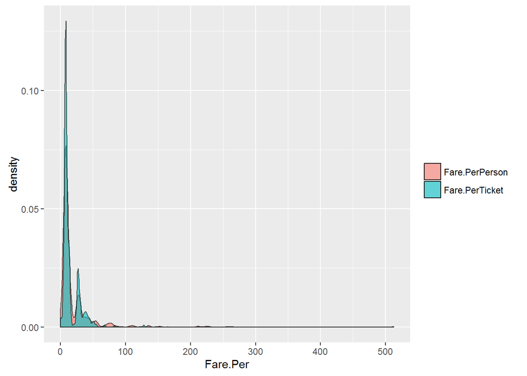

```r
fare.per <- stack(combi[,c("Fare.PerPerson","Fare.PerTicket")])
ggplot(fare.per, aes(x = values)) +
    geom_density(aes(fill = ind), alpha = 0.6) +
    labs(x = 'Fare.Per', fill = '')
```

**interesting facts**

`Ticket.Count` / `Fare.PerTicket` and `Family.Size` / `Fare.PerPerson` are ones of the most important variables in several machine learning algorithms I tested. `Fare.PerTicket` returns reasonable per person price in cases where `Fare.PerPerson` looked suspicious.

### Family Name

I think `Name` column deserves more attention. For example, family names can be extracted and build clusters based on them. As there can be two diferent family groups traveling under the same family name, I will concatenate family name, `Family.Size` and `Ticket.Name` to encode the `Family.Name`. I will create another codification for a reduced family name (`Family.NameSimple`), combining in a single group passengers with family size below three and low frequency groupings (threshold set to 3).

```r
surname <- sapply(combi$Name, FUN = function(x) {
    strsplit(x, split = '[,.]')[[1]][1]
})
combi$Family.Name <- paste(surname, as.character(combi$Family.Size), combi$Ticket.Name, sep = "_")

# reduce groups size
combi$Family.NameSimple <- combi$Family.Name
combi$Family.NameSimple[combi$Family.Size <= 2] <- 'Small'
# Delete erroneous family IDs
famIDs <- table(combi$Family.NameSimple)
famIDs <- rownames(famIDs[famIDs <= 2])
combi$Family.NameSimple[combi$Family.NameSimple %in% famIDs] <- 'Small'
# Convert to factor
combi$Family.NameSimple <- factor(combi$Family.NameSimple)
rm(famIDs, surname)
```

### Cabin

77% of the passengers haven’t got cabin data. Figuring out the cabin might be a *fortune-telling* task, but guessing the deck can be more *realistic* based upon `Ticket` and `Fare` data, and the deck is also a good location feature.

The first imputation we will test will be using `Ticket` information, as probably tickets belonging to the same class and ticket name, would occupy *nearby* cabins

My trick would be to imputate cabin data using as reference other cabins with the same ticket. As seen before, there are seldom cases of same-ticket passengers spread along several cabins, but even in former rare cases, they stay on the same deck and most of the times, in contigous cabins.

```r
predictCabinByTicket <- function(data, rows.filter) {
    ticket.cabin <- data %>%
        filter(!is.na(Cabin)) %>%
        group_by(Ticket, Cabin) %>%
        summarise(max (n())) %>%
        group_by(Ticket) %>%
        summarize_each(funs(first)) %>%
        mutate (Cabin.Extended = Cabin) %>%
        select (Ticket, Cabin.Extended)

    rj <- right_join(ticket.cabin, data)
    return (rj$Cabin.Extended[rows.filter])
}

cabin.extended <- combi$Cabin
rows.fix.cabin.by.ticket <- which(is.na(cabin.extended))
# check NA's count before predict (should be 0)
sum(!is.na(cabin.extended[rows.fix.cabin.by.ticket]))
```

```
## [1] 0
```

```r
cabin.extended[rows.fix.cabin.by.ticket] <- predictCabinByTicket(combi, rows.fix.cabin.by.ticket)
```

safe check

Let’s take a look to the *new discovered* cabins

```r
combi[rows.fix.cabin.by.ticket,] %>%
    mutate (Cabin.Extended = cabin.extended[rows.fix.cabin.by.ticket]) %>%
    filter (!is.na(Cabin.Extended)) %>%
    select (Cabin.Extended, Cabin, Ticket, Pclass) %>%
    arrange (Pclass, Ticket)
```

```
## Source: local data frame [16 x 4]
##
##     Cabin.Extended Cabin      Ticket Pclass
##              (chr) (chr)       (chr) (fctr)
## 1          C22 C26    NA      113781      1
## 2          C22 C26    NA      113781      1
## 3              C68    NA       17421      1
## 4              C46    NA       19877      1
## 5               B3    NA       24160      1
## 6               C7    NA       36928      1
## 7               C7    NA       36928      1
## 8  B57 B59 B63 B66    NA    PC 17608      1
## 9             B101    NA    PC 17755      1
## 10             C45    NA    PC 17757      1
## 11             C45    NA    PC 17757      1
## 12             C32    NA    PC 17760      1
## 13             C86    NA    PC 17761      1
## 14             E77    NA S.O./P.P. 3      2
## 15           F E69    NA        2668      3
## 16           F E69    NA        2668      3
```

What we did was to imputate cabin data, taking as reference the cabin most used by the ticket. In order to do so, we’d need another ticket where we have cabin data. For example, let’s check `"PC 17760"` ticket case:

```r
(.lastVal = combi %>% filter (Ticket == "PC 17760") %>% select (Ticket, Name, Cabin))
```

```
## Source: local data frame [4 x 3]
## Groups: <by row>
##
##     Ticket                                  Name Cabin
##      (chr)                                 (chr) (chr)
## 1 PC 17760                Bissette, Miss. Amelia   C99
## 2 PC 17760              Young, Miss. Marie Grice   C32
## 3 PC 17760                   Ringhini, Mr. Sante    NA
## 4 PC 17760 White, Mrs. John Stuart (Ella Holmes)   C32
```

Traveling with the same ticket, we got cabins C99, C32 , but we imputate the most frequent one, which is C32

In conclussion, using this procedure, we figure out 16 cabin values. I will move this new data into a new column named `Cabin.Extended` and this data will be used to generate `Side` and `Deck` information.

```r
combi$Cabin.Extended <- cabin.extended
```

### Deck

Passenger’s deck may be inferred from `Cabin` data (deck is the letter that appears on cabin values).

```r
sample(unique(combi$Cabin),30)
```

```
##  [1] "D"           "F2"          "C70"         "E101"        "A21"         "D33"         "C62 C64"     "F33"
##  [9] "C110"        "A16"         "B58 B60"     "C89"         "E49"         "C92"         "B52 B54 B56" "E17"
## [17] "B37"         "D11"         "B38"         "B30"         "E45"         "D48"         "A10"         "D21"
## [25] "C97"         "D34"         "D38"         "B45"         "B36"         "B77"
```

| Letter | Deck |  |
| --- | --- | --- |
| A | Upper Promenade (Boat ) Deck | 1st class Staterooms 1st class Lounge 1st and 2nd class Promenade |
| B | Promenade Deck | 1st class Suites and Cabins with Bath 1st class Staterooms Library 1st and 2nd class Promenade |
| C | Bridge Deck | 1st class Apartments and Cabins de Luxe 2nd class Promenade Third class Social Hall |
| D | Shelter Deck | 1st class Staterooms 3rd class Rooms 2nd class Staterooms |
| E | Saloon Deck | 1st and 2nd class Staterooms 3rd class Rooms |
| F | Upper Deck | 2nd class Staterooms 3rd class Rooms |
| G | Middle Deck | 3rd class Rooms |
|  | Lower Deck | Meat chambers, Cargo and Coal bunkers |
|  | Orlop Deck | Cargo and Coal bunkers |
|  | Tank Top Deck |  |

Deck information extracted from [Titanic](http://www.icyousee.org/titanic.html) and [The Levels of the Titanic](http://rmstitanic1912.weebly.com/the-levels-of-the-titanic.html)

```r
deck <- substring(combi$Cabin.Extended, 1, 1)
# only purpose for Cabin.Extended is to infer Deck location
#combi$Cabin.Extended <- NULL
rows.fix.cabin.unk <- is.na(deck)
deck[rows.fix.cabin.unk] <- "UNK"
combi$Deck <- deck
rm(deck)

.lastVal = prop.table(table(rows.fix.cabin.unk))
```

As mentioned before, `Deck` an be extracted from `Cabin` data. Problem is that cabin information is scarce (24% of known values), so I’ve got my own doubts about its usefulness.

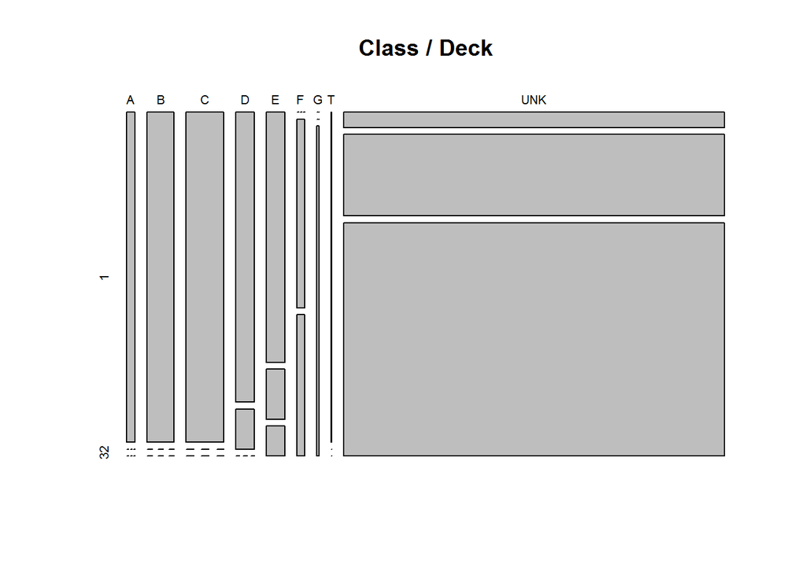

```r
plot(table(combi$Deck[rows.train], combi$Pclass[rows.train]), dnn=c("Deck","Class"), main="Class / Deck")
```

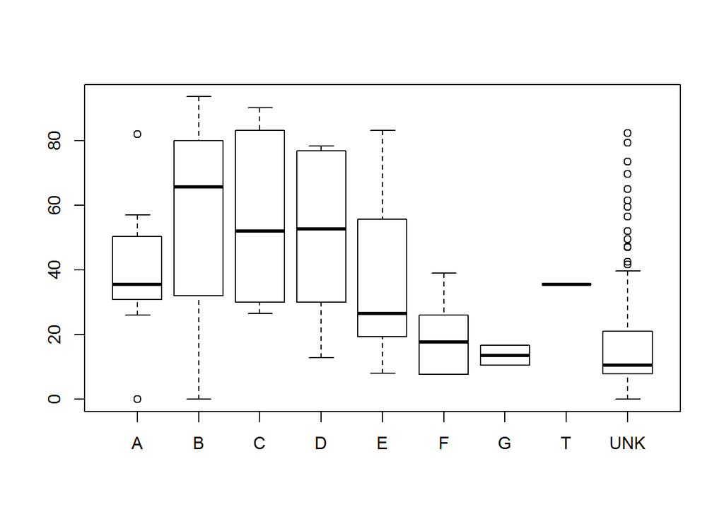

```r
boxplot(Fare ~ Deck, combi[rows.train & combi$Fare < 100,])
```

Looking at the plots, there is a single passenger which deck seems not valid:

```r
rows.fix.deck.t <- combi$Deck == "T"
combi[rows.fix.deck.t, c("Name","Cabin.Extended","Pclass","Ticket","Fare","Family.Size","Ticket.Count")]
```

```
## Source: local data frame [1 x 7]
##
##                           Name Cabin.Extended Pclass Ticket  Fare Family.Size Ticket.Count
##                          (chr)          (chr) (fctr)  (chr) (dbl)       (dbl)        (dbl)
## 1 Blackwell, Mr. Stephen Weart              T      1 113784  35.5           1            1
```

It looks like a lonely passenger, but is travelling in deck T … is this an error on the data? Looking for more information about [Blackwell, Mr. Stephen Weart](http://www.encyclopedia-titanica.org/titanic-victim/stephen-weart-blackwell.html) we find out that:

> They met up with Ms. Bonnell and the family of George Dennick Wick while touring France, and they boarded the Titanic together in Southampton, Blackwell occupied cabin “T” on the Boat Deck (ticket number 113784, £35 10s).

So correct deck for this passenger should be “A” (boat deck).

```r
rows.fix.deck.g <- combi$Deck == "G"
kable(combi[rows.fix.deck.g, c("Name","Cabin.Extended","Pclass","Ticket","Fare","Family.Size")] %>% arrange(Ticket))
```

| Name | Cabin.Extended | Pclass | Ticket | Fare | Family.Size |
| --- | --- | --- | --- | --- | --- |
| Strom, Miss. Telma Matilda | G6 | 3 | 347054 | 10.4625 | 2 |
| Strom, Mrs. Wilhelm (Elna Matilda Persson) | G6 | 3 | 347054 | 10.4625 | 3 |
| Sandstrom, Miss. Marguerite Rut | G6 | 3 | PP 9549 | 16.7000 | 3 |
| Sandstrom, Mrs. Hjalmar (Agnes Charlotta Bengtsson) | G6 | 3 | PP 9549 | 16.7000 | 3 |
| Sandstrom, Miss. Beatrice Irene | G6 | 3 | PP 9549 | 16.7000 | 3 |

```r
combi$Deck[rows.fix.deck.g] <- "F"
combi$Deck[rows.fix.deck.t] <- "A"

rows.fix.deck.unk.temp <- combi$Pclass == 3 & combi$Fare > 0
tapply(combi$Fare.PerPerson[rows.fix.deck.unk.temp], combi$Deck[rows.fix.deck.unk.temp], summary)
```

```
## $E
##    Min. 1st Qu.  Median    Mean 3rd Qu.    Max.
##   6.238   6.238   6.238   6.842   7.144   8.050
##
## $F
##    Min. 1st Qu.  Median    Mean 3rd Qu.    Max.
##   3.488   5.567   7.453   6.706   7.650   7.750
##
## $UNK
##    Min. 1st Qu.  Median    Mean 3rd Qu.    Max.
##   1.111   6.875   7.750   8.046   8.050  56.500
```

```r
tapply(combi$Fare[rows.fix.deck.unk.temp], combi$Deck[rows.fix.deck.unk.temp], summary)
```

```
## $E
##    Min. 1st Qu.  Median    Mean 3rd Qu.    Max.
##    8.05   10.26   12.48   11.00   12.48   12.48
##
## $F
##    Min. 1st Qu.  Median    Mean 3rd Qu.    Max.
##   7.229   7.650  10.460  12.730  16.700  22.360
##
## $UNK
##    Min. 1st Qu.  Median    Mean 3rd Qu.    Max.
##   3.171   7.750   8.050  13.400  15.210  69.550
```

Using the boxplot (ignoring outliers), we know that most of the unknown cabins paid less than 20 pounds, so they can’t belong to A, B or C decks, where most people belonged to first and second class. The mosaic plot confirms that most passengers with unknown Cabin belong to third class passengers. So we can extract a rule, for unknown deck passengers from third class paying the cheapest tickets, and move them to deck F.

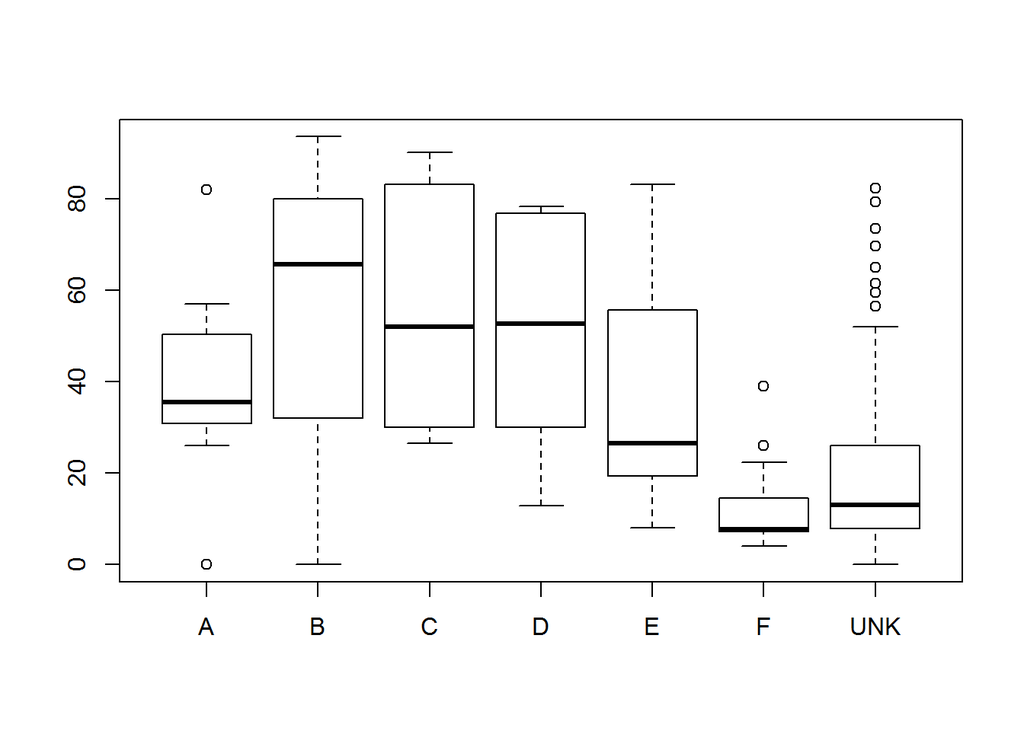

```r
rows.fix.deck.unk <- (combi$Deck == "UNK" & combi$Pclass == "3" & combi$Fare < 22.360 & combi$Fare.PerPerson < 7.750 & combi$Fare > 0)
combi$Deck[rows.fix.deck.unk] <- "F"
combi$Deck <- factor(combi$Deck)

boxplot(Fare ~ Deck, combi[rows.train & combi$Fare < 100,])
```

### Side

```r
sample(unique(combi$Cabin[!is.na(combi$Cabin)]),30)
```

```
##  [1] "C55 C57"         "B51 B53 B55"     "D6"              "C54"             "C89"             "C99"
##  [7] "C50"             "A24"             "C132"            "B57 B59 B63 B66" "B22"             "C101"
## [13] "F E46"           "E38"             "B19"             "D7"              "B41"             "C28"
## [19] "A36"             "D38"             "E52"             "E101"            "D35"             "C23 C25 C27"
## [25] "E63"             "B30"             "C92"             "C110"            "A6"              "C97"
```

The problem is that the cabin data is not complete neither normalized. The best case is when the cabin value is like “A26”, which univocally identify deck and cabin.

```r
inferSideProb <- function(cabin){
    if (!is.array(cabin) && is.na(cabin)) return (NA_real_)
    cabins <- unique(unlist(strsplit(cabin, " ")))
    return (mean(as.numeric(str_sub(cabins, -1)) %% 2, na.rm = T))
}

inferSide <- function(sideProb) {
    if (is.na(sideProb) || is.nan(sideProb)) return (3)
    if (sideProb == 0) return (0)
    if (sideProb == 1) return (1)
    if (sideProb > 0 && sideProb < 1) return (2)
    return (3)
}

predictSideProbByCabin <- function(data) {
    data %>% rowwise() %>% mutate (Side.Prob = inferSideProb(Cabin.Extended))
}

predictSide <- function(data) {
    data <- data %>% rowwise() %>% mutate(Side = inferSide(Side.Prob))
    data$Side <- factor(data$Side)
    levels(data$Side) <- c("starboard","port", "prob","unknown")
    return (data)
}

combi <- predictSide(predictSideProbByCabin(combi))
```

safe check

Let’s review some special cases … how many “cabins” contains spaces?

```r
rows.cabin.space <- grepl(" ", combi$Cabin)
unique(combi$Cabin[rows.cabin.space])
```

```
##  [1] "C23 C25 C27"     "F G73"           "D10 D12"         "B58 B60"         "F E69"           "C22 C26"
##  [7] "B57 B59 B63 B66" "B96 B98"         "B51 B53 B55"     "F G63"           "C62 C64"         "B82 B84"
## [13] "C55 C57"         "F E46"           "F E57"           "E39 E41"         "B52 B54 B56"
```

Cabins in former case are contiguous (`"B96 B98"` or `"D10 D12"`). There is only a single case where the side probability is not convenient (cabin `"B57 B59 B63 B66"`), as this “cabin” mixes odd and even cabins. In this case, the ratio between odd and even is the side probability (3/4).

```r
combi %>%
    filter (Cabin %in% c("B57 B59 B63 B66","F G73","B96 B98")) %>%
    select (Pclass, Ticket, Cabin, Side, Side.Prob) %>%
    arrange (Ticket, Cabin)
```

```
## Source: local data frame [11 x 5]
##
##    Pclass   Ticket           Cabin      Side Side.Prob
##    (fctr)    (chr)           (chr)    (fctr)     (dbl)
## 1       1   113760         B96 B98 starboard      0.00
## 2       1   113760         B96 B98 starboard      0.00
## 3       1   113760         B96 B98 starboard      0.00
## 4       1   113760         B96 B98 starboard      0.00
## 5       3   348123           F G73      port      1.00
## 6       3   348124           F G73      port      1.00
## 7       1 PC 17608 B57 B59 B63 B66      prob      0.75
## 8       1 PC 17608 B57 B59 B63 B66      prob      0.75
## 9       1 PC 17608 B57 B59 B63 B66      prob      0.75
## 10      1 PC 17608 B57 B59 B63 B66      prob      0.75
## 11      1 PC 17608 B57 B59 B63 B66      prob      0.75
```

Finally, `Side` is a categorical feature, based on the data returned by `Side.Prob`

```r
table(combi$Side)
```

```
##
## starboard      port      prob   unknown
##       160       139         6      1004
```

```r
(.lastVal = sum(is.na(combi$Cabin) | is.nan(combi$Side.Prob)))
```

```
## [1] 1020
```

```r
combi %>%
    filter (!is.na(Cabin) & Side == "unknown") %>%
    select (Ticket, Pclass, Cabin, Side, Side.Prob)
```

```
## Source: local data frame [6 x 5]
## Groups: <by row>
##
##            Ticket Pclass Cabin    Side Side.Prob
##             (chr) (fctr) (chr)  (fctr)     (dbl)
## 1   SC/Paris 2163      2     D unknown       NaN
## 2           28551      2     D unknown       NaN
## 3          113784      1     T unknown       NaN
## 4 SC/AH Basle 541      2     D unknown       NaN
## 5          248734      2     F unknown       NaN
## 6          237735      2     D unknown       NaN
```

The second trick will be based on `Fare` and `Pclass` data: the fares show a regular distribution of values, based on the class, so nearby cabins within the same class, share same fare.

```r
predictCabinByFare <- function(data, rows.filter) {
    ticket.fare <- data %>%
        filter(!is.na(Cabin.Extended) & Fare > 0) %>%
        group_by(Fare.PerPerson, Embarked, Pclass, Cabin.Extended) %>%
        summarise(max (n())) %>%
        group_by(Fare.PerPerson, Embarked, Pclass) %>%
        summarize_each(funs(first)) %>%
        mutate (Cabin.Extended2 = Cabin.Extended) %>%
        select (Fare.PerPerson, Embarked, Pclass, Cabin.Extended2)

    rj <- right_join(ticket.fare, data)
    return (rj$Cabin.Extended2[rows.filter])
}

rows.fix.cabin.by.fare <- which(is.na(cabin.extended))
# check NA's count before predict (should be 0)
sum(!is.na(cabin.extended[rows.fix.cabin.by.fare]))
```

```
## [1] 0
```

```r
cabin.extended[rows.fix.cabin.by.fare] <- predictCabinByFare(combi, rows.fix.cabin.by.fare)
```

safe check

We check imputation results

```r
combi[rows.fix.cabin.by.fare,] %>%
    mutate (Cabin.Extended = cabin.extended[rows.fix.cabin.by.fare]) %>%
    filter (!is.na(Cabin.Extended)) %>%
    select (Cabin.Extended, Cabin, Ticket, Pclass, Fare, Fare.PerPerson) %>%
    arrange (Pclass, Ticket)
```

```
## Source: local data frame [308 x 6]
##
##    Cabin.Extended Cabin Ticket Pclass    Fare Fare.PerPerson
##             (chr) (chr)  (chr) (fctr)   (dbl)          (dbl)
## 1             A19    NA 111163      1 26.0000        26.0000
## 2             B38    NA 111427      1 26.5500        26.5500
## 3             B38    NA 111428      1 26.5500        26.5500
## 4             A11    NA 112377      1 27.7208        27.7208
## 5             A18    NA 112378      1 59.4000        29.7000
## 6             A18    NA 112378      1 59.4000        29.7000
## 7             A19    NA 113789      1 52.0000        26.0000
## 8             A19    NA 113789      1 52.0000        26.0000
## 9             B38    NA 113790      1 26.5500        26.5500
## 10            B38    NA 113791      1 26.5500        26.5500
## ..            ...   ...    ...    ...     ...            ...
```

```r
# check NA's count after predict (should be greather than 0)
(.lastVal <- sum(!is.na(cabin.extended[rows.fix.cabin.by.fare])))
```

```
## [1] 308
```

Another 308 values …. not bad at all

## Processing

Check final dataset structure

```r
glimpse(combi, 100)
```

```
## Observations: 1,309
## Variables: 30
## $ PassengerId       (int) 1, 2, 3, 4, 5, 6, 7, 8, 9, 10, 11, 12, 13, 14, 15, 16, 17, 18, 19, 20...
## $ Survived          (int) 0, 1, 1, 1, 0, 0, 0, 0, 1, 1, 1, 1, 0, 0, 0, 1, 0, 1, 0, 1, 0, 1, 1, ...
## $ Pclass            (fctr) 3, 1, 3, 1, 3, 3, 1, 3, 3, 2, 3, 1, 3, 3, 3, 2, 3, 2, 3, 3, 2, 2, 3,...
## $ Name              (chr) "Braund, Mr. Owen Harris", "Cumings, Mrs. John Bradley (Florence Brig...
## $ Sex               (fctr) male, female, female, female, male, male, male, male, female, female...
## $ Age               (dbl) 22.0, 38.0, 26.0, 35.0, 35.0, 25.0, 54.0, 2.0, 27.0, 14.0, 4.0, 58.0,...
## $ SibSp             (int) 1, 1, 0, 1, 0, 0, 0, 3, 0, 1, 1, 0, 0, 1, 0, 0, 4, 0, 1, 0, 0, 0, 0, ...
## $ Parch             (int) 0, 0, 0, 0, 0, 0, 0, 1, 2, 0, 1, 0, 0, 5, 0, 0, 1, 0, 0, 0, 0, 0, 0, ...
## $ Ticket            (chr) "A/5 21171", "PC 17599", "STON/O2. 3101282", "113803", "373450", "330...
## $ Fare              (dbl) 7.2500, 71.2833, 7.9250, 53.1000, 8.0500, 8.4583, 51.8625, 21.0750, 1...
## $ Cabin             (chr) NA, "C85", NA, "C123", NA, NA, "E46", NA, NA, NA, "G6", "C103", NA, N...
## $ Embarked          (fctr) S, C, S, S, S, Q, S, S, S, C, S, S, S, S, S, S, Q, S, S, C, S, S, Q,...
## $ Title             (fctr) Mr, Mrs, Miss, Mrs, Mr, Mr, Mr, Master, Mrs, Mrs, Miss, Miss, Mr, Mr...
```

[output cut: 17 more lines]

After finishing pre-processing, we split back data into training and test sets. Then we split the training set in two batches, 80% for training and 20% for model validation

```r
library(caret)
train.pre <- combi[rows.train,]
train.pre$Fate <- factor(train.pre$Survived)
levels(train.pre$Fate) <- c("perished", "survived")
test.pre <- combi[!rows.train,]
test.pre$Survived <- NULL

rows.batch <- createDataPartition(train.pre$Survived, p = 0.8, list = FALSE)
train.batch <- train.pre[rows.batch,]
test.batch <- train.pre[-rows.batch,]
```

## Single Model

Load libraries for machine learning classification

```r
suppressMessages(library(doParallel)) # parallel procesing via cores
registerDoParallel(2)
suppressMessages(library(glmnet)) # linear regression
suppressMessages(library(randomForest)) # random forests
#library(rpart)
#library(party)
library(knitr)
suppressMessages(library(pROC)) # ROC curves
suppressMessages(library(adabag)) # ada bootsrapping
suppressMessages(library(gbm)) # stochastic gradient boosting
```

### Generic Linear Model

We will train a model using a GLM function, based on the train / predict functions from the caret package.

```r
trc.recv <- trainControl(method = "repeatedcv", repeats = 10, summaryFunction = twoClassSummary, classProbs = TRUE)
```

We will define an small helper function in order to describe the model formulated using several descriptions

```r
model.summary <- function (train.model, data = test.batch, procCM = T) {
    if (train.model$method == "glm")
    {
        message("ANOVA")
        print(anova(train.model$finalModel, test = "Chisq"))
    } else if (train.model$method == "gbm" || train.model$method == "glm") {
        message("SUMMARY")
        print (summary(train.model))
    } else {
        message("SUMMARY")
        print (train.model)
    }

    if (train.model$method != "knn")
    {
        message ("VARIMP")
        print (varImp(train.model))
    }

    pred <- predict(train.model, data)
    if (procCM)
    {
        message("Confusion Matrix")
        print (confusionMatrix(pred, data$Fate, positive="survived"))
        print (roc(as.numeric(pred), as.numeric(data$Fate), auc=T))
    }
    return (pred)
}
```

```r
train.glm <- train(Fate ~ Sex + Pclass + Fare + Sex:Pclass + Family.Size + Title + Age, data = train.batch, method = "glm", metric = "ROC", trControl = trc.recv)
```

show model summary

```r
results.glm <- model.summary(train.glm)
```

```
## ANOVA
```

```
## Analysis of Deviance Table
##
## Model: binomial, link: logit
##
## Response: .outcome
##
## Terms added sequentially (first to last)
##
##
##                   Df Deviance Resid. Df Resid. Dev  Pr(>Chi)
## NULL                                712     953.57
## Sexmale            1  202.936       711     750.64 < 2.2e-16 ***
## Pclass2            1    1.474       710     749.16  0.224787
## Pclass3            1   62.075       709     687.09 3.305e-15 ***
## Fare               1    0.183       708     686.90  0.668702
## Family.Size        1    7.309       707     679.60  0.006863 **
## TitleMiss          1    0.410       706     679.18  0.521730
## TitleMr            1   34.804       705     644.38 3.646e-09 ***
## TitleMrs           1    0.145       704     644.24  0.703557
## TitleNoble         1   34.150       703     610.09 5.103e-09 ***
## Age                1    4.723       702     605.36  0.029756 *
## `Sexmale:Pclass2`  1    9.905       701     595.46  0.001648 **
## `Sexmale:Pclass3`  1    4.680       700     590.78  0.030523 *
## ---
## Signif. codes:  0 '***' 0.001 '**' 0.01 '*' 0.05 '.' 0.1 ' ' 1
```

```
## VARIMP
```

```
## glm variable importance
##
##                     Overall
## TitleMr           100.00000
## Family.Size        82.15912
## Pclass3            69.60369
## TitleNoble         59.56313
## Age                32.98731
## `Sexmale:Pclass3`  31.85344
## Pclass2            19.65448
## Fare               13.39653
## `Sexmale:Pclass2`  13.15413
## Sexmale             0.02278
## TitleMiss           0.01191
## TitleMrs            0.00000
```

```
## Confusion Matrix
```

```
## Confusion Matrix and Statistics
##
##           Reference
## Prediction perished survived
##   perished      105       16
##   survived        9       48
##
##                Accuracy : 0.8596
##                  95% CI : (0.7997, 0.907)
##     No Information Rate : 0.6404
##     P-Value [Acc > NIR] : 5.408e-11
##
##                   Kappa : 0.6875
##  Mcnemar's Test P-Value : 0.2301
##
##             Sensitivity : 0.7500
##             Specificity : 0.9211
##          Pos Pred Value : 0.8421
##          Neg Pred Value : 0.8678
##              Prevalence : 0.3596
##          Detection Rate : 0.2697
##    Detection Prevalence : 0.3202
##       Balanced Accuracy : 0.8355
##
##        'Positive' Class : survived
##
##
## Call:
## roc.default(response = as.numeric(pred), predictor = as.numeric(data$Fate),     auc = T)
##
## Data: as.numeric(data$Fate) in 121 controls (as.numeric(pred) 1) < 57 cases (as.numeric(pred) 2).
## Area under the curve: 0.8549
```

### KNN

```r
trc.knn <- trainControl(method = "repeatedcv", repeats = 10, summaryFunction = twoClassSummary, classProbs = TRUE)
train.knn <- train(Fate ~ Sex + Pclass + Fare.PerPerson + Family.Size + Title + Age + Family.NameSimple , train.batch, method = "knn", trControl = trc.knn, metric = "ROC", preProcess = c("center", "scale", "nzv"), tuneLength=5)
```

show model summary

```r
results.knn <- model.summary(train.knn)
```

```
## SUMMARY
```

```
## k-Nearest Neighbors
##
## 713 samples
##  30 predictor
##   2 classes: 'perished', 'survived'
##
## Pre-processing: centered (10), scaled (10), remove (59)
## Resampling: Cross-Validated (10 fold, repeated 10 times)
## Summary of sample sizes: 641, 642, 641, 642, 643, 642, ...
## Resampling results across tuning parameters:
##
##   k   ROC        Sens       Spec       ROC SD      Sens SD     Spec SD
##    5  0.8500338  0.8785888  0.6808201  0.04561695  0.04965994  0.07953825
##    7  0.8510696  0.8820085  0.6669048  0.04254773  0.05132129  0.08056132
##    9  0.8516745  0.8785677  0.6471429  0.04382081  0.05005482  0.08649827
##   11  0.8472813  0.8831924  0.6306217  0.04596789  0.04947713  0.08775557
##   13  0.8417604  0.8877748  0.6078704  0.04545690  0.04913674  0.09004476
##
## ROC was used to select the optimal model using  the largest value.
## The final value used for the model was k = 9.
```

```
## Confusion Matrix
```

```
## Confusion Matrix and Statistics
##
##           Reference
## Prediction perished survived
##   perished      104       19
##   survived       10       45
##
##                Accuracy : 0.8371
##                  95% CI : (0.7745, 0.8881)
##     No Information Rate : 0.6404
##     P-Value [Acc > NIR] : 5.365e-09
##
##                   Kappa : 0.635
##  Mcnemar's Test P-Value : 0.1374
##
##             Sensitivity : 0.7031
##             Specificity : 0.9123
##          Pos Pred Value : 0.8182
##          Neg Pred Value : 0.8455
##              Prevalence : 0.3596
##          Detection Rate : 0.2528
##    Detection Prevalence : 0.3090
##       Balanced Accuracy : 0.8077
##
##        'Positive' Class : survived
##
##
## Call:
## roc.default(response = as.numeric(pred), predictor = as.numeric(data$Fate),     auc = T)
##
## Data: as.numeric(data$Fate) in 123 controls (as.numeric(pred) 1) < 55 cases (as.numeric(pred) 2).
## Area under the curve: 0.8319
```

### Random Forest

```r
train.rf <- train(Fate ~ Sex + Pclass + Fare.PerPerson + Family.Size + Title + Age + Ticket.Count + Deck, train.batch, method = "rf", metric = "ROC", trControl = trc.recv, tuneLength=5)
```

show model summary

```r
results.rf <- model.summary(train.rf)
```

```
## SUMMARY
```

```
## Random Forest
##
## 713 samples
##  30 predictor
##   2 classes: 'perished', 'survived'
##
## No pre-processing
## Resampling: Cross-Validated (10 fold, repeated 10 times)
## Summary of sample sizes: 642, 642, 642, 642, 641, 642, ...
## Resampling results across tuning parameters:
##
##   mtry  ROC        Sens       Spec       ROC SD      Sens SD     Spec SD
##    2    0.8605321  0.8894503  0.7224735  0.04986612  0.04437195  0.08901220
##    5    0.8679627  0.8913372  0.7095238  0.04598100  0.04934871  0.09010120
##    9    0.8642785  0.8858562  0.7019974  0.04541832  0.05064393  0.09301504
##   13    0.8605698  0.8695137  0.7009656  0.04635525  0.05291752  0.09695315
##   17    0.8573948  0.8632981  0.6984788  0.04622141  0.05219437  0.09425982
##
## ROC was used to select the optimal model using  the largest value.
## The final value used for the model was mtry = 5.
```

```
## VARIMP
```

```
## rf variable importance
##
##                 Overall
## Fare.PerPerson 100.0000
## TitleMr         90.6910
## Age             85.9921
## Sexmale         73.1777
## Ticket.Count    36.1564
## Family.Size     32.7877
## Pclass3         25.4408
## TitleMrs        17.6863
## TitleMiss       17.5105
## DeckUNK         10.5681
## DeckE            4.1856
## TitleNoble       3.8586
## Pclass2          2.9340
## DeckF            1.6367
## DeckC            0.9630
## DeckD            0.1272
## DeckB            0.0000
```

```
## Confusion Matrix
```

```
## Confusion Matrix and Statistics
##
##           Reference
## Prediction perished survived
##   perished       99       12
##   survived       15       52
##
##                Accuracy : 0.8483
##                  95% CI : (0.787, 0.8976)
##     No Information Rate : 0.6404
##     P-Value [Acc > NIR] : 5.863e-10
##
##                   Kappa : 0.674
##  Mcnemar's Test P-Value : 0.7003
##
##             Sensitivity : 0.8125
##             Specificity : 0.8684
##          Pos Pred Value : 0.7761
##          Neg Pred Value : 0.8919
##              Prevalence : 0.3596
##          Detection Rate : 0.2921
##    Detection Prevalence : 0.3764
##       Balanced Accuracy : 0.8405
##
##        'Positive' Class : survived
##
##
## Call:
## roc.default(response = as.numeric(pred), predictor = as.numeric(data$Fate),     auc = T)
##
## Data: as.numeric(data$Fate) in 111 controls (as.numeric(pred) 1) < 67 cases (as.numeric(pred) 2).
## Area under the curve: 0.834
```

```r
train.rf <- train(Fate ~ Sex + Pclass + Fare.PerPerson + Family.Size + Title + Age + Ticket.Count + Deck + Age.IsMother + Age.IsChild, train.batch, method = "rf", metric = "ROC", trControl = trc.recv, tuneLength=5)
```

show model summary

```r
results.rf <- model.summary(train.rf)
```

```
## SUMMARY
```

```
## Random Forest
##
## 713 samples
##  30 predictor
##   2 classes: 'perished', 'survived'
##
## No pre-processing
## Resampling: Cross-Validated (10 fold, repeated 10 times)
## Summary of sample sizes: 641, 642, 642, 641, 643, 642, ...
## Resampling results across tuning parameters:
##
##   mtry  ROC        Sens       Spec       ROC SD      Sens SD     Spec SD
##    2    0.8605380  0.8901268  0.7059656  0.04394165  0.04738299  0.07856299
##    6    0.8686333  0.8900581  0.7109259  0.04251353  0.05195275  0.07622046
##   10    0.8651116  0.8808457  0.7070238  0.04270121  0.04964409  0.07467657
##   14    0.8602562  0.8601321  0.7071032  0.04404076  0.05173826  0.07543661
##   19    0.8588240  0.8557928  0.6980159  0.04404851  0.04934686  0.08230411
##
## ROC was used to select the optimal model using  the largest value.
## The final value used for the model was mtry = 6.
```

```
## VARIMP
```

```
## rf variable importance
##
##                  Overall
## Fare.PerPerson   100.000
## Age               87.596
## Sexmale           81.798
## TitleMr           79.249
## Ticket.Count      37.123
## Family.Size       34.096
## Pclass3           24.197
## TitleMiss         16.994
## TitleMrs          14.955
## DeckUNK           10.625
## Age.IsChildTRUE    6.011
## DeckE              5.534
## Pclass2            4.264
## TitleNoble         4.159
## DeckF              2.996
## DeckC              2.089
## DeckD              1.829
## DeckB              1.105
## Age.IsMotherTRUE   0.000
```

```
## Confusion Matrix
```

```
## Confusion Matrix and Statistics
##
##           Reference
## Prediction perished survived
##   perished       99       12
##   survived       15       52
##
##                Accuracy : 0.8483
##                  95% CI : (0.787, 0.8976)
##     No Information Rate : 0.6404
##     P-Value [Acc > NIR] : 5.863e-10
##
##                   Kappa : 0.674
##  Mcnemar's Test P-Value : 0.7003
##
##             Sensitivity : 0.8125
##             Specificity : 0.8684
##          Pos Pred Value : 0.7761
##          Neg Pred Value : 0.8919
##              Prevalence : 0.3596
##          Detection Rate : 0.2921
##    Detection Prevalence : 0.3764
##       Balanced Accuracy : 0.8405
##
##        'Positive' Class : survived
##
##
## Call:
## roc.default(response = as.numeric(pred), predictor = as.numeric(data$Fate),     auc = T)
##
## Data: as.numeric(data$Fate) in 111 controls (as.numeric(pred) 1) < 67 cases (as.numeric(pred) 2).
## Area under the curve: 0.834
```

```r
train.rf <- train(Fate ~ Sex + Pclass + Fare.PerPerson + Family.Size + Title + Age + Ticket.Count + Ticket.Name, train.pre, method = "rf", metric = "ROC", trControl = trc.recv, tuneLength=5)
```

show model summary

```r
#results.rf <- model.summary(train.rf, test.pre, F)
#result <- data.frame(Survived = as.numeric(results.rf) - 1, PassengerId = test.pre$PassengerId)
#write.csv(result, "../titanic/titanic.csv", quote=F, row.names=F)
```

```r
train.rf <- train(Fate ~ Sex + Pclass + Fare.PerPerson + Family.Size + Title + Age + Ticket.Count + Ticket.Name, train.batch, method = "rf", metric = "ROC", trControl = trc.recv, tuneLength=5)
```

show model summary

```r
results.rf <- model.summary(train.rf)
```

```
## SUMMARY
```

```
## Random Forest
##
## 713 samples
##  30 predictor
##   2 classes: 'perished', 'survived'
##
## No pre-processing
## Resampling: Cross-Validated (10 fold, repeated 10 times)
## Summary of sample sizes: 643, 641, 643, 641, 641, 642, ...
## Resampling results across tuning parameters:
##
##   mtry  ROC        Sens       Spec       ROC SD      Sens SD     Spec SD
##    2    0.8511465  0.8960941  0.6868254  0.04586353  0.04513277  0.07666822
##    9    0.8778243  0.8952273  0.7151984  0.03567010  0.04647120  0.06895595
##   16    0.8739750  0.8782135  0.7109259  0.03495627  0.04335673  0.07186971
##   23    0.8697944  0.8713425  0.7130291  0.03501870  0.04405773  0.07143213
##   31    0.8661848  0.8646670  0.7130159  0.03644466  0.04609696  0.07319439
##
## ROC was used to select the optimal model using  the largest value.
## The final value used for the model was mtry = 9.
```

```
## VARIMP
```

```
## rf variable importance
##
##   only 20 most important variables shown (out of 31)
##
##                Overall
## Fare.PerPerson 100.000
## TitleMr         90.176
## Age             87.790
## Sexmale         83.388
## Ticket.Count    42.581
## Family.Size     35.663
## Pclass3         31.407
## TitleMiss       22.255
## TitleMrs        19.532
## TitleNoble       7.126
## Ticket.NameUNK   7.073
## Pclass2          7.049
## Ticket.NameST3   5.827
## Ticket.NameSW2   5.322
## Ticket.NamePP1   3.816
## Ticket.NameWC3   2.805
## Ticket.NameSO3   2.519
## Ticket.NameCS3   1.879
## Ticket.NameSP2   1.818
## Ticket.NameSC2   1.036
```

```
## Confusion Matrix
```

```
## Confusion Matrix and Statistics
##
##           Reference
## Prediction perished survived
##   perished      102       13
##   survived       12       51
##
##                Accuracy : 0.8596
##                  95% CI : (0.7997, 0.907)
##     No Information Rate : 0.6404
##     P-Value [Acc > NIR] : 5.408e-11
##
##                   Kappa : 0.694
##  Mcnemar's Test P-Value : 1
##
##             Sensitivity : 0.7969
##             Specificity : 0.8947
##          Pos Pred Value : 0.8095
##          Neg Pred Value : 0.8870
##              Prevalence : 0.3596
##          Detection Rate : 0.2865
##    Detection Prevalence : 0.3539
##       Balanced Accuracy : 0.8458
##
##        'Positive' Class : survived
##
##
## Call:
## roc.default(response = as.numeric(pred), predictor = as.numeric(data$Fate),     auc = T)
##
## Data: as.numeric(data$Fate) in 115 controls (as.numeric(pred) 1) < 63 cases (as.numeric(pred) 2).
## Area under the curve: 0.8482
```

```r
train.rf <- train(Fate ~ Sex + Pclass + Fare.PerPerson + Family.Size + Title + Age + Ticket.Count + Ticket.Name + Age.IsChild, train.batch, method = "rf", metric = "ROC", trControl = trc.recv, tuneLength=5)
```

show model summary

```r
results.rf <- model.summary(train.rf)
```

```
## SUMMARY
```

```
## Random Forest
##
## 713 samples
##  30 predictor
##   2 classes: 'perished', 'survived'
##
## No pre-processing
## Resampling: Cross-Validated (10 fold, repeated 10 times)
## Summary of sample sizes: 642, 641, 642, 641, 642, 642, ...
## Resampling results across tuning parameters:
##
##   mtry  ROC        Sens       Spec       ROC SD      Sens SD     Spec SD
##    2    0.8533444  0.8976110  0.6870106  0.04729616  0.04751298  0.09117806
##    9    0.8747591  0.8969873  0.7071561  0.04152864  0.05303818  0.08478123
##   17    0.8711385  0.8762949  0.7112302  0.04122403  0.05556085  0.08020653
##   24    0.8669653  0.8655074  0.7141005  0.04054221  0.05607317  0.08120366
##   32    0.8639701  0.8590592  0.7144841  0.04030857  0.05486209  0.07674316
##
## ROC was used to select the optimal model using  the largest value.
## The final value used for the model was mtry = 9.
```

```
## VARIMP
```

```
## rf variable importance
##
##   only 20 most important variables shown (out of 32)
##
##                 Overall
## Fare.PerPerson  100.000
## Sexmale          86.669
## TitleMr          81.260
## Age              79.963
## Ticket.Count     40.335
## Family.Size      34.920
## Pclass3          29.691
## TitleMiss        20.185
## TitleMrs         19.097
## Age.IsChildTRUE   9.982
## Pclass2           7.090
## TitleNoble        6.889
## Ticket.NameUNK    6.865
## Ticket.NameSW2    5.677
## Ticket.NameST3    5.396
## Ticket.NamePP1    3.951
## Ticket.NameWC3    3.308
## Ticket.NameSO3    2.265
## Ticket.NameSP2    1.865
## Ticket.NameCS3    1.783
```

```
## Confusion Matrix
```

```
## Confusion Matrix and Statistics
##
##           Reference
## Prediction perished survived
##   perished      102       15
##   survived       12       49
##
##                Accuracy : 0.8483
##                  95% CI : (0.787, 0.8976)
##     No Information Rate : 0.6404
##     P-Value [Acc > NIR] : 5.863e-10
##
##                   Kappa : 0.6672
##  Mcnemar's Test P-Value : 0.7003
##
##             Sensitivity : 0.7656
##             Specificity : 0.8947
##          Pos Pred Value : 0.8033
##          Neg Pred Value : 0.8718
##              Prevalence : 0.3596
##          Detection Rate : 0.2753
##    Detection Prevalence : 0.3427
##       Balanced Accuracy : 0.8302
##
##        'Positive' Class : survived
##
##
## Call:
## roc.default(response = as.numeric(pred), predictor = as.numeric(data$Fate),     auc = T)
##
## Data: as.numeric(data$Fate) in 117 controls (as.numeric(pred) 1) < 61 cases (as.numeric(pred) 2).
## Area under the curve: 0.8375
```

```r
train.rf <- train(Fate ~ Sex + Pclass + Fare.PerPerson + Family.Size + Title + Age + Ticket.Count, train.batch, method = "rf", metric = "ROC", trControl = trc.recv, tuneLength=5)
```

show model summary

```r
results.rf <- model.summary(train.rf)
```

```
## SUMMARY
```

```
## Random Forest
##
## 713 samples
##  30 predictor
##   2 classes: 'perished', 'survived'
##
## No pre-processing
## Resampling: Cross-Validated (10 fold, repeated 10 times)
## Summary of sample sizes: 641, 642, 641, 643, 641, 642, ...
## Resampling results across tuning parameters:
##
##   mtry  ROC        Sens       Spec       ROC SD      Sens SD     Spec SD
##    2    0.8610235  0.8922304  0.7171032  0.04146668  0.04369736  0.07983791
##    4    0.8716320  0.9000846  0.7181878  0.03783116  0.04261560  0.07896868
##    6    0.8679435  0.8920032  0.7124339  0.03790827  0.04358204  0.07647708
##    8    0.8629031  0.8715539  0.7134921  0.03859284  0.04724276  0.07596232
##   11    0.8574412  0.8648943  0.7070370  0.03996272  0.04829902  0.07755755
##
## ROC was used to select the optimal model using  the largest value.
## The final value used for the model was mtry = 4.
```

```
## VARIMP
```

```
## rf variable importance
##
##                 Overall
## Fare.PerPerson 100.0000
## Age             85.8339
## Sexmale         81.3465
## TitleMr         70.5299
## Ticket.Count    34.7020
## Family.Size     29.0017
## Pclass3         20.8345
## TitleMrs        11.3434
## TitleMiss       10.0587
## TitleNoble       0.9848
## Pclass2          0.0000
```

```
## Confusion Matrix
```

```
## Confusion Matrix and Statistics
##
##           Reference
## Prediction perished survived
##   perished      103       12
##   survived       11       52
##
##                Accuracy : 0.8708
##                  95% CI : (0.8124, 0.9163)
##     No Information Rate : 0.6404
##     P-Value [Acc > NIR] : 4.163e-12
##
##                   Kappa : 0.7185
##  Mcnemar's Test P-Value : 1
##
##             Sensitivity : 0.8125
##             Specificity : 0.9035
##          Pos Pred Value : 0.8254
##          Neg Pred Value : 0.8957
##              Prevalence : 0.3596
##          Detection Rate : 0.2921
##    Detection Prevalence : 0.3539
##       Balanced Accuracy : 0.8580
##
##        'Positive' Class : survived
##
##
## Call:
## roc.default(response = as.numeric(pred), predictor = as.numeric(data$Fate),     auc = T)
##
## Data: as.numeric(data$Fate) in 115 controls (as.numeric(pred) 1) < 63 cases (as.numeric(pred) 2).
## Area under the curve: 0.8605
```

```r
train.rf.best <- train(Fate ~ Sex + Pclass + Fare.PerPerson + Family.Size + Title + Age, train.batch, method = "rf", metric = "ROC", trControl = trc.recv, tuneLength=5)
```

show model summary

```r
results.rf.best <- model.summary(train.rf.best)
```

```
## SUMMARY
```

```
## Random Forest
##
## 713 samples
##  30 predictor
##   2 classes: 'perished', 'survived'
##
## No pre-processing
## Resampling: Cross-Validated (10 fold, repeated 10 times)
## Summary of sample sizes: 642, 641, 642, 642, 642, 643, ...
## Resampling results across tuning parameters:
##
##   mtry  ROC        Sens       Spec       ROC SD      Sens SD     Spec SD
##    2    0.8571914  0.8942653  0.7093915  0.04920090  0.05003779  0.08486095
##    4    0.8694813  0.9094609  0.7147354  0.04585060  0.04392600  0.08781211
##    6    0.8655369  0.8944873  0.7194577  0.04261242  0.04075900  0.08833002
##    8    0.8593608  0.8756290  0.7147619  0.04170074  0.04289087  0.08638979
##   10    0.8553178  0.8696776  0.7100661  0.04120787  0.04543463  0.08522861
##
## ROC was used to select the optimal model using  the largest value.
## The final value used for the model was mtry = 4.
```

```
## VARIMP
```

```
## rf variable importance
##
##                Overall
## Fare.PerPerson 100.000
## Age             86.729
## TitleMr         81.055
## Sexmale         72.894
## Family.Size     39.414
## Pclass3         24.382
## TitleMiss        8.082
## TitleMrs         8.037
## TitleNoble       1.526
## Pclass2          0.000
```

```
## Confusion Matrix
```

```
## Confusion Matrix and Statistics
##
##           Reference
## Prediction perished survived
##   perished      103       12
##   survived       11       52
##
##                Accuracy : 0.8708
##                  95% CI : (0.8124, 0.9163)
##     No Information Rate : 0.6404
##     P-Value [Acc > NIR] : 4.163e-12
##
##                   Kappa : 0.7185
##  Mcnemar's Test P-Value : 1
##
##             Sensitivity : 0.8125
##             Specificity : 0.9035
##          Pos Pred Value : 0.8254
##          Neg Pred Value : 0.8957
##              Prevalence : 0.3596
##          Detection Rate : 0.2921
##    Detection Prevalence : 0.3539
##       Balanced Accuracy : 0.8580
##
##        'Positive' Class : survived
##
##
## Call:
## roc.default(response = as.numeric(pred), predictor = as.numeric(data$Fate),     auc = T)
##
## Data: as.numeric(data$Fate) in 115 controls (as.numeric(pred) 1) < 63 cases (as.numeric(pred) 2).
## Area under the curve: 0.8605
```

### Conditional Random Forest

```r
train.rf <- train(Fate ~ Sex + Pclass + Fare.PerPerson + Family.Size + Title + Age + Ticket.Count + Ticket.Name, train.batch, method = "cforest", trControl = trc.recv, tuneLength=5)
```

show model summary

```r
results.rf <- model.summary(train.rf)
```

```
## SUMMARY
```

```
## Conditional Inference Random Forest
##
## 713 samples
##  30 predictor
##   2 classes: 'perished', 'survived'
##
## No pre-processing
## Resampling: Cross-Validated (10 fold, repeated 10 times)
## Summary of sample sizes: 642, 641, 641, 642, 642, 642, ...
## Resampling results across tuning parameters:
##
##   mtry  ROC        Sens       Spec       ROC SD      Sens SD     Spec SD
##    2    0.8373341  1.0000000  0.0000000  0.05010941  0.00000000  0.00000000
##    9    0.8515289  0.8943499  0.6647619  0.05017386  0.04684477  0.08829385
##   16    0.8644180  0.8938901  0.7115476  0.04828659  0.04729571  0.08427428
##   23    0.8702502  0.8950423  0.7141402  0.04521792  0.04812621  0.08659053
##   31    0.8718727  0.9005550  0.6870899  0.04491451  0.04811396  0.09034045
##
## ROC was used to select the optimal model using  the largest value.
## The final value used for the model was mtry = 31.
```

```
## VARIMP
```

```
## cforest variable importance
##
##   only 20 most important variables shown (out of 31)
##
##                 Overall
## TitleMr        100.0000
## Pclass3         39.6549
## Sexmale         26.4466
## TitleNoble      13.3773
## Ticket.Count    12.4550
## Family.Size     11.5882
## Fare.PerPerson  11.1709
## Age              4.1736
## Pclass2          2.5047
## Ticket.NameST3   0.7461
## Ticket.NameSW2   0.5164
## Ticket.NameWC3   0.4968
## Ticket.NameCS3   0.4927
## Ticket.NameCA2   0.4828
## Ticket.NameSO3   0.4828
## Ticket.NameSC2   0.4787
## Ticket.NameFC1   0.4783
## Ticket.NameFA3   0.4783
## Ticket.NameWP1   0.4783
## Ticket.NameWC2   0.4783
```

```
## Confusion Matrix
```

```
## Confusion Matrix and Statistics
##
##           Reference
## Prediction perished survived
##   perished      104       15
##   survived       10       49
##
##                Accuracy : 0.8596
##                  95% CI : (0.7997, 0.907)
##     No Information Rate : 0.6404
##     P-Value [Acc > NIR] : 5.408e-11
##
##                   Kappa : 0.6897
##  Mcnemar's Test P-Value : 0.4237
##
##             Sensitivity : 0.7656
##             Specificity : 0.9123
##          Pos Pred Value : 0.8305
##          Neg Pred Value : 0.8739
##              Prevalence : 0.3596
##          Detection Rate : 0.2753
##    Detection Prevalence : 0.3315
##       Balanced Accuracy : 0.8390
##
##        'Positive' Class : survived
##
##
## Call:
## roc.default(response = as.numeric(pred), predictor = as.numeric(data$Fate),     auc = T)
##
## Data: as.numeric(data$Fate) in 119 controls (as.numeric(pred) 1) < 59 cases (as.numeric(pred) 2).
## Area under the curve: 0.8522
```

### C5.0

```r
train.c5 <- train(Fate ~ Sex + Pclass + Fare.PerPerson + Family.Size + Title + Age + Ticket.Count + Ticket.Name, train.batch, method = "C5.0", metric = "ROC", trControl = trc.recv, tuneLength=5)
```

show model summary

```r
results.c5 <- model.summary(train.c5)
```

```
## SUMMARY
```

```
## C5.0
##
## 713 samples
##  30 predictor
##   2 classes: 'perished', 'survived'
##
## No pre-processing
## Resampling: Cross-Validated (10 fold, repeated 10 times)
## Summary of sample sizes: 641, 641, 642, 641, 641, 643, ...
## Resampling results across tuning parameters:
##
##   model  winnow  trials  ROC        Sens       Spec       ROC SD      Sens SD     Spec SD
##   rules  FALSE    1      0.8141785  0.8848573  0.6733201  0.04686278  0.05369068  0.10350851
##   rules  FALSE   10      0.8679671  0.8873784  0.7131085  0.04257091  0.04121189  0.08753386
##   rules  FALSE   20      0.8716076  0.8804545  0.7198677  0.04109374  0.04332119  0.08182754
##   rules  FALSE   30      0.8726841  0.8795666  0.7191667  0.04049039  0.04447024  0.08728958
##   rules  FALSE   40      0.8729151  0.8800264  0.7177249  0.04000394  0.04652440  0.08862783
##   rules   TRUE    1      0.7979790  0.8773996  0.6956746  0.06027074  0.05570776  0.09094584
##   rules   TRUE   10      0.8553771  0.8841438  0.7191402  0.04520297  0.04742643  0.08658526
##   rules   TRUE   20      0.8571927  0.8818499  0.7194048  0.04426716  0.04547245  0.08578708
##   rules   TRUE   30      0.8570447  0.8795825  0.7230291  0.04383386  0.04862847  0.08815033
##   rules   TRUE   40      0.8571029  0.8802801  0.7237302  0.04437703  0.04948805  0.08987299
##   tree   FALSE    1      0.8483945  0.8832875  0.6956349  0.04934651  0.05155237  0.10103459
##   tree   FALSE   10      0.8693917  0.8940592  0.6972354  0.04321792  0.04497069  0.09352809
##   tree   FALSE   20      0.8737388  0.8926586  0.7007672  0.03924364  0.04266206  0.09143082
##   tree   FALSE   30      0.8740873  0.8924207  0.7032672  0.04015024  0.04304721  0.08830920
##   tree   FALSE   40      0.8760332  0.8896670  0.7011243  0.03950006  0.04525991  0.08997094
##   tree    TRUE    1      0.8298693  0.8833932  0.7075529  0.04910401  0.05065195  0.08921318
##   tree    TRUE   10      0.8576065  0.8859091  0.7118386  0.04362150  0.05028591  0.08989646
##   tree    TRUE   20      0.8587692  0.8854968  0.7114683  0.04300060  0.04904583  0.08242173
##   tree    TRUE   30      0.8585273  0.8832188  0.7107407  0.04494210  0.04922437  0.08854341
##   tree    TRUE   40      0.8592788  0.8822939  0.7114550  0.04329975  0.05100578  0.08487772
##
## ROC was used to select the optimal model using  the largest value.
## The final values used for the model were trials = 40, model = tree and winnow = FALSE.
```

```
## VARIMP
```

```
## C5.0 variable importance
##
##   only 20 most important variables shown (out of 31)
##
##                Overall
## Ticket.Count    100.00
## Ticket.NameST3  100.00
## TitleMr         100.00
## TitleNoble      100.00
## Pclass2         100.00
## Fare.PerPerson  100.00
## Pclass3         100.00
## Family.Size     100.00
## Sexmale         100.00
## Ticket.NameSO3  100.00
## Age              99.58
## Ticket.NamePP1   98.88
## TitleMrs         96.63
## Ticket.NameUNK   91.87
## Ticket.NameSW2   72.93
## Ticket.NameSP2   33.94
## TitleMiss        27.91
## Ticket.NameWC3    9.54
## Ticket.NameWP1    0.00
## Ticket.NameFA3    0.00
```

```
## Confusion Matrix
```

```
## Confusion Matrix and Statistics
##
##           Reference
## Prediction perished survived
##   perished      102       17
##   survived       12       47
##
##                Accuracy : 0.8371
##                  95% CI : (0.7745, 0.8881)
##     No Information Rate : 0.6404
##     P-Value [Acc > NIR] : 5.365e-09
##
##                   Kappa : 0.6401
##  Mcnemar's Test P-Value : 0.4576
##
##             Sensitivity : 0.7344
##             Specificity : 0.8947
##          Pos Pred Value : 0.7966
##          Neg Pred Value : 0.8571
##              Prevalence : 0.3596
##          Detection Rate : 0.2640
##    Detection Prevalence : 0.3315
##       Balanced Accuracy : 0.8146
##
##        'Positive' Class : survived
##
##
## Call:
## roc.default(response = as.numeric(pred), predictor = as.numeric(data$Fate),     auc = T)
##
## Data: as.numeric(data$Fate) in 119 controls (as.numeric(pred) 1) < 59 cases (as.numeric(pred) 2).
## Area under the curve: 0.8269
```

```r
train.c5.best <- train(Fate ~ Sex + Pclass + Fare.PerPerson + Family.Size + Title + Age + Ticket.Count + Family.NameSimple, train.batch, method = "C5.0", metric = "ROC", trControl = trc.recv, tuneLength=5)
```

show model summary

```r
results.c5.best <- model.summary(train.c5.best)
```

```
## SUMMARY
```

```
## C5.0
##
## 713 samples
##  30 predictor
##   2 classes: 'perished', 'survived'
##
## No pre-processing
## Resampling: Cross-Validated (10 fold, repeated 10 times)
## Summary of sample sizes: 641, 641, 642, 642, 642, 642, ...
## Resampling results across tuning parameters:
##
##   model  winnow  trials  ROC        Sens       Spec       ROC SD      Sens SD     Spec SD
##   rules  FALSE    1      0.8118299  0.8729228  0.7034656  0.08760187  0.05749841  0.10898810
##   rules  FALSE   10      0.8695727  0.8768129  0.7274471  0.04441445  0.05479802  0.08940183
##   rules  FALSE   20      0.8730739  0.8726797  0.7342593  0.04155042  0.05257158  0.09379916
##   rules  FALSE   30      0.8735051  0.8680603  0.7447354  0.04199812  0.05502553  0.08584357
##   rules  FALSE   40      0.8735230  0.8703753  0.7412037  0.04380719  0.05455081  0.08949015
##   rules   TRUE    1      0.8058282  0.8740486  0.7124206  0.05174195  0.05756489  0.10196797
##   rules   TRUE   10      0.8562645  0.8770349  0.7239021  0.04855334  0.05261866  0.09155972
##   rules   TRUE   20      0.8606265  0.8712315  0.7303704  0.04923380  0.05633806  0.08647980
##   rules   TRUE   30      0.8613495  0.8687421  0.7371693  0.04886813  0.05749777  0.08951782
##   rules   TRUE   40      0.8616762  0.8703488  0.7342857  0.04952424  0.05713135  0.08970632
##   tree   FALSE    1      0.8515809  0.8807664  0.7060185  0.04423663  0.05641986  0.10284783
##   tree   FALSE   10      0.8719184  0.8937791  0.7184392  0.04303322  0.04851049  0.08819805
##   tree   FALSE   20      0.8761418  0.8850687  0.7206878  0.04327686  0.05278410  0.08481871
##   tree   FALSE   30      0.8773663  0.8827907  0.7159524  0.04268983  0.05284788  0.08849325
##   tree   FALSE   40      0.8800579  0.8873837  0.7188889  0.04289848  0.05133542  0.08724843
##   tree    TRUE    1      0.8301441  0.8793393  0.7177910  0.05165175  0.05535355  0.10551778
##   tree    TRUE   10      0.8580468  0.8862526  0.7182011  0.04879664  0.05002476  0.08992821
##   tree    TRUE   20      0.8620190  0.8809884  0.7207672  0.04776365  0.05246198  0.08853515
##   tree    TRUE   30      0.8630701  0.8772622  0.7239683  0.04709958  0.05230622  0.08989832
##   tree    TRUE   40      0.8630611  0.8804863  0.7258069  0.04833642  0.05144058  0.09184407
##
## ROC was used to select the optimal model using  the largest value.
## The final values used for the model were trials = 40, model = tree and winnow = FALSE.
```

```
## VARIMP
```

```
## C5.0 variable importance
##
##   only 20 most important variables shown (out of 71)
##
##                                Overall
## Pclass3                         100.00
## Family.Size                     100.00
## Sexmale                         100.00
## TitleMr                         100.00
## TitleNoble                      100.00
## TitleMiss                       100.00
## TitleMrs                        100.00
## Fare.PerPerson                  100.00
## Ticket.Count                    100.00
## Pclass2                         100.00
## Age                             100.00
## Family.NameSimpleSmall          100.00
## Family.NameSimpleAsplund_7_UNK   76.72
## Family.NameSimpleAllison_4_UNK   42.78
## Family.NameSimpleVanImpe_3_UNK   26.93
## Family.NameSimpleCarter_4_UNK     5.47
## Family.NameSimplePeter_3_UNK      2.81
## Family.NameSimpleTouma_3_UNK      2.66
## Family.NameSimpleThayer_3_UNK     0.00
## Family.NameSimpleBecker_4_UNK     0.00
```

```
## Confusion Matrix
```

```
## Confusion Matrix and Statistics
##
##           Reference
## Prediction perished survived
##   perished      101       12
##   survived       13       52
##
##                Accuracy : 0.8596
##                  95% CI : (0.7997, 0.907)
##     No Information Rate : 0.6404
##     P-Value [Acc > NIR] : 5.408e-11
##
##                   Kappa : 0.6961
##  Mcnemar's Test P-Value : 1
##
##             Sensitivity : 0.8125
##             Specificity : 0.8860
##          Pos Pred Value : 0.8000
##          Neg Pred Value : 0.8938
##              Prevalence : 0.3596
##          Detection Rate : 0.2921
##    Detection Prevalence : 0.3652
##       Balanced Accuracy : 0.8492
##
##        'Positive' Class : survived
##
##
## Call:
## roc.default(response = as.numeric(pred), predictor = as.numeric(data$Fate),     auc = T)
##
## Data: as.numeric(data$Fate) in 113 controls (as.numeric(pred) 1) < 65 cases (as.numeric(pred) 2).
## Area under the curve: 0.8469
```

```r
train.c5 <- train(Fate ~ Sex + Pclass + Fare.PerPerson + Family.Size + Title + Age + Ticket.Count + Family.NameSimple + Embarked, train.batch, method = "C5.0", metric = "ROC", trControl = trc.recv, tuneLength=5)
```

show model summary

```r
results.c5 <- model.summary(train.c5)
```

```
## SUMMARY
```

```
## C5.0
##
## 713 samples
##  30 predictor
##   2 classes: 'perished', 'survived'
##
## No pre-processing
## Resampling: Cross-Validated (10 fold, repeated 10 times)
## Summary of sample sizes: 642, 641, 642, 641, 641, 642, ...
## Resampling results across tuning parameters:
##
##   model  winnow  trials  ROC        Sens       Spec       ROC SD      Sens SD     Spec SD
##   rules  FALSE    1      0.8201887  0.8775317  0.6945238  0.05037002  0.05847575  0.09195956
##   rules  FALSE   10      0.8637641  0.8815116  0.7071561  0.04253453  0.05100445  0.08422595
##   rules  FALSE   20      0.8665798  0.8717918  0.7256217  0.04374978  0.05080950  0.08246924
##   rules  FALSE   30      0.8678445  0.8687949  0.7320635  0.04378569  0.04945518  0.08681199
##   rules  FALSE   40      0.8668778  0.8715856  0.7305820  0.04321102  0.05231805  0.08577538
##   rules   TRUE    1      0.8014257  0.8789218  0.6921561  0.04782087  0.05023620  0.08085420
##   rules   TRUE   10      0.8532612  0.8805497  0.7075661  0.04705070  0.04781124  0.07586260
##   rules   TRUE   20      0.8544423  0.8764218  0.7082143  0.04700757  0.05084699  0.08290182
##   rules   TRUE   30      0.8540935  0.8718076  0.7169048  0.04716187  0.05444664  0.08243059
##   rules   TRUE   40      0.8560151  0.8722992  0.7143651  0.04714440  0.05309153  0.08136082
##   tree   FALSE    1      0.8530537  0.8834989  0.6982143  0.04294694  0.04804716  0.08509241
##   tree   FALSE   10      0.8646703  0.8895507  0.7022090  0.04522071  0.05147262  0.09245232
##   tree   FALSE   20      0.8675661  0.8888214  0.7046032  0.04489237  0.05279180  0.08329565
##   tree   FALSE   30      0.8673497  0.8879175  0.7020767  0.04491037  0.05377299  0.08673878
##   tree   FALSE   40      0.8693867  0.8881395  0.7057011  0.04593547  0.05156513  0.08814664
##   tree    TRUE    1      0.8274013  0.8858140  0.6989550  0.05167126  0.05167879  0.07903081
##   tree    TRUE   10      0.8521088  0.8853436  0.6982143  0.04579327  0.05158995  0.08036760
##   tree    TRUE   20      0.8547788  0.8831078  0.7061772  0.04627899  0.05640909  0.08534569
##   tree    TRUE   30      0.8534660  0.8833404  0.7018783  0.04754395  0.05331483  0.08469966
##   tree    TRUE   40      0.8558615  0.8847199  0.7079762  0.04674814  0.05337539  0.08187446
##
## ROC was used to select the optimal model using  the largest value.
## The final values used for the model were trials = 40, model = tree and winnow = FALSE.
```

```
## VARIMP
```

```
## C5.0 variable importance
##
##   only 20 most important variables shown (out of 72)
##
##                                 Overall
## EmbarkedQ                        100.00
## Ticket.Count                     100.00
## Family.Size                      100.00
## Sexmale                          100.00
## EmbarkedS                        100.00
## TitleMr                          100.00
## Pclass3                          100.00
## Fare.PerPerson                   100.00
## Family.NameSimpleSmall            97.34
## TitleNoble                        97.34
## Age                               96.77
## Pclass2                           92.99
## TitleMrs                          87.52
## TitleMiss                         44.04
## Family.NameSimpleAsplund_7_UNK    33.94
## Family.NameSimpleAllison_4_UNK    19.07
## Family.NameSimpleRice_6_UNK        0.00
## Family.NameSimpleWidener_3_UNK     0.00
## Family.NameSimpleCaldwell_3_UNK    0.00
## Family.NameSimpleGoodwin_8_SO3     0.00
```

```
## Confusion Matrix
```

```
## Confusion Matrix and Statistics
##
##           Reference
## Prediction perished survived
##   perished      102       16
##   survived       12       48
##
##                Accuracy : 0.8427
##                  95% CI : (0.7807, 0.8929)
##     No Information Rate : 0.6404
##     P-Value [Acc > NIR] : 1.81e-09
##
##                   Kappa : 0.6537
##  Mcnemar's Test P-Value : 0.5708
##
##             Sensitivity : 0.7500
##             Specificity : 0.8947
##          Pos Pred Value : 0.8000
##          Neg Pred Value : 0.8644
##              Prevalence : 0.3596
##          Detection Rate : 0.2697
##    Detection Prevalence : 0.3371
##       Balanced Accuracy : 0.8224
##
##        'Positive' Class : survived
##
##
## Call:
## roc.default(response = as.numeric(pred), predictor = as.numeric(data$Fate),     auc = T)
##
## Data: as.numeric(data$Fate) in 118 controls (as.numeric(pred) 1) < 60 cases (as.numeric(pred) 2).
## Area under the curve: 0.8322
```

```r
set.seed(428)
train.c5 <- train(Fate ~ Sex + Pclass + Fare.PerPerson + Family.Size + Title + Age + Ticket.Count + Family.NameSimple + Embarked, train.batch, method = "C5.0", metric = "ROC", trControl = trc.recv)
```

show model summary

```r
results.c5 <- model.summary(train.c5)
```

```
## SUMMARY
```

```
## C5.0
##
## 713 samples
##  30 predictor
##   2 classes: 'perished', 'survived'
##
## No pre-processing
## Resampling: Cross-Validated (10 fold, repeated 10 times)
## Summary of sample sizes: 642, 643, 641, 641, 642, 642, ...
## Resampling results across tuning parameters:
##
##   model  winnow  trials  ROC        Sens       Spec       ROC SD      Sens SD     Spec SD
##   rules  FALSE    1      0.8197680  0.8782452  0.6901058  0.05334639  0.05676850  0.09557192
##   rules  FALSE   10      0.8679273  0.8791121  0.7170899  0.04426032  0.05171166  0.09450174
##   rules  FALSE   20      0.8692438  0.8820930  0.7217989  0.04380204  0.04829609  0.09304251
##   rules   TRUE    1      0.8030525  0.8767600  0.6940873  0.06498629  0.05382698  0.09045863
##   rules   TRUE   10      0.8561969  0.8890222  0.7110185  0.04991202  0.04711689  0.08843328
##   rules   TRUE   20      0.8585742  0.8871776  0.7056746  0.04957751  0.05270204  0.08680001
##   tree   FALSE    1      0.8508742  0.8839376  0.7005423  0.04931233  0.04929871  0.09291535
##   tree   FALSE   10      0.8680612  0.8890275  0.7113757  0.04645203  0.05407864  0.08921891
##   tree   FALSE   20      0.8702651  0.8906290  0.7134656  0.04596755  0.04498098  0.08376745
##   tree    TRUE    1      0.8298158  0.8855655  0.6987831  0.05215756  0.04976700  0.09255901
##   tree    TRUE   10      0.8568618  0.8871882  0.7178042  0.05010740  0.05102574  0.08938460
##   tree    TRUE   20      0.8586645  0.8883034  0.7121693  0.05101007  0.04809488  0.09392710
##
## ROC was used to select the optimal model using  the largest value.
## The final values used for the model were trials = 20, model = tree and winnow = FALSE.
```

```
## VARIMP
```

```
## C5.0 variable importance
##
##   only 20 most important variables shown (out of 72)
##
##                                Overall
## TitleMr                         100.00
## Sexmale                         100.00
## Family.Size                     100.00
## Ticket.Count                    100.00
## EmbarkedQ                       100.00
## Fare.PerPerson                  100.00
## Pclass2                         100.00
## Pclass3                         100.00
## Age                              99.58
## TitleMrs                         87.52
## EmbarkedS                        72.23
## Family.NameSimpleSmall           66.34
## TitleNoble                       53.16
## Family.NameSimpleAsplund_7_UNK   26.23
## TitleMiss                        25.53
## Family.NameSimpleDavies_3_A3      0.00
## Family.NameSimpleDodge_3_UNK      0.00
## Family.NameSimpleFord_5_WC3       0.00
## Family.NameSimpleTaussig_3_UNK    0.00
## Family.NameSimpleWick_3_UNK       0.00
```

```
## Confusion Matrix
```

```
## Confusion Matrix and Statistics
##
##           Reference
## Prediction perished survived
##   perished      101       12
##   survived       13       52
##
##                Accuracy : 0.8596
##                  95% CI : (0.7997, 0.907)
##     No Information Rate : 0.6404
##     P-Value [Acc > NIR] : 5.408e-11
##
##                   Kappa : 0.6961
##  Mcnemar's Test P-Value : 1
##
##             Sensitivity : 0.8125
##             Specificity : 0.8860
##          Pos Pred Value : 0.8000
##          Neg Pred Value : 0.8938
##              Prevalence : 0.3596
##          Detection Rate : 0.2921
##    Detection Prevalence : 0.3652
##       Balanced Accuracy : 0.8492
##
##        'Positive' Class : survived
##
##
## Call:
## roc.default(response = as.numeric(pred), predictor = as.numeric(data$Fate),     auc = T)
##
## Data: as.numeric(data$Fate) in 113 controls (as.numeric(pred) 1) < 65 cases (as.numeric(pred) 2).
## Area under the curve: 0.8469
```

```r
set.seed(9834)
tuneGrid <- expand.grid(trials=c(30,40,50,60), winnow=FALSE, model="rules")
train.c5 <- train(Fate ~ Sex + Pclass + Fare.PerPerson + Family.Size + Title + Age + Ticket.Count + Family.NameSimple + Embarked, train.batch, method = "C5.0", metric = "ROC", trControl = trc.recv, tuneGrid=tuneGrid)
```

show model summary

```r
results.c5 <- model.summary(train.c5)
```

```
## SUMMARY
```

[output not shown]

```
## VARIMP
```

```
## C5.0 variable importance
##
##   only 20 most important variables shown (out of 72)
##
##                                Overall
## TitleMr                         100.00
## Pclass3                         100.00
## Family.Size                     100.00
## Fare.PerPerson                  100.00
## Ticket.Count                    100.00
## Pclass2                         100.00
## EmbarkedQ                       100.00
## Sexmale                         100.00
## Age                              99.58
## TitleMrs                         87.52
## EmbarkedS                        72.23
## Family.NameSimpleSmall           66.34
## TitleNoble                       53.16
## Family.NameSimpleAsplund_7_UNK   26.23
## TitleMiss                        25.53
## Family.NameSimpleSamaan_3_UNK     0.00
## Family.NameSimplePanula_6_UNK     0.00
## Family.NameSimpleDanbom_3_UNK     0.00
## Family.NameSimpleCompton_3_PP1    0.00
## Family.NameSimpleElias_3_UNK      0.00
```

```
## Confusion Matrix
```

```
## Confusion Matrix and Statistics
##
##           Reference
## Prediction perished survived
##   perished      101       12
##   survived       13       52
##
##                Accuracy : 0.8596
##                  95% CI : (0.7997, 0.907)
##     No Information Rate : 0.6404
##     P-Value [Acc > NIR] : 5.408e-11
##
##                   Kappa : 0.6961
##  Mcnemar's Test P-Value : 1
##
##             Sensitivity : 0.8125
##             Specificity : 0.8860
##          Pos Pred Value : 0.8000
##          Neg Pred Value : 0.8938
##              Prevalence : 0.3596
##          Detection Rate : 0.2921
##    Detection Prevalence : 0.3652
##       Balanced Accuracy : 0.8492
##
##        'Positive' Class : survived
##
##
## Call:
## roc.default(response = as.numeric(pred), predictor = as.numeric(data$Fate),     auc = T)
##
## Data: as.numeric(data$Fate) in 113 controls (as.numeric(pred) 1) < 65 cases (as.numeric(pred) 2).
## Area under the curve: 0.8469
```

### ADA boost

```r
train.ada <- train(Fate ~ Sex + Pclass + Fare.PerPerson + Family.Size + Title + Age + Ticket.Count + Family.NameSimple + Embarked, train.batch, method = "AdaBoost.M1", metric = "ROC", trControl = trc.recv)
```

show model summary

```r
results.ada <- model.summary(train.ada)
```

### Stochastic Gradient Boosting

```r
train.gbm <- train(Fate ~ Sex + Pclass + Fare.PerPerson + Family.Size + Title + Age + Ticket.Count + Family.NameSimple + Embarked, train.batch, method = "gbm", metric = "ROC", trControl = trc.recv)
```

show model summary

```r
results.gbm <- model.summary(train.gbm)
```

```
## SUMMARY
```

```
##                                                                   var    rel.inf
## TitleMr                                                       TitleMr 23.3961966
## Fare.PerPerson                                         Fare.PerPerson 22.6572693
## Sexmale                                                       Sexmale 17.1220434
## Age                                                               Age 14.5097556
## Family.Size                                               Family.Size  6.4285554
## Ticket.Count                                             Ticket.Count  4.7498392
## Pclass3                                                       Pclass3  4.4754010
## TitleNoble                                                 TitleNoble  2.2628033
## TitleMrs                                                     TitleMrs  1.4724916
## EmbarkedS                                                   EmbarkedS  1.2410713
## TitleMiss                                                   TitleMiss  0.8280129
## EmbarkedQ                                                   EmbarkedQ  0.6148478
## Pclass2                                                       Pclass2  0.1255112
## Family.NameSimpleSmall                         Family.NameSimpleSmall  0.1162013
## Family.NameSimpleAllison_4_UNK         Family.NameSimpleAllison_4_UNK  0.0000000
## Family.NameSimpleAndersson_7_UNK     Family.NameSimpleAndersson_7_UNK  0.0000000
## Family.NameSimpleAsplund_7_UNK         Family.NameSimpleAsplund_7_UNK  0.0000000
## Family.NameSimpleBaclini_4_UNK         Family.NameSimpleBaclini_4_UNK  0.0000000
## Family.NameSimpleBecker_4_UNK           Family.NameSimpleBecker_4_UNK  0.0000000
## Family.NameSimpleBoulos_3_UNK           Family.NameSimpleBoulos_3_UNK  0.0000000
## Family.NameSimpleBourke_3_UNK           Family.NameSimpleBourke_3_UNK  0.0000000
## Family.NameSimpleBrown_3_UNK             Family.NameSimpleBrown_3_UNK  0.0000000
## Family.NameSimpleCaldwell_3_UNK       Family.NameSimpleCaldwell_3_UNK  0.0000000
## Family.NameSimpleCarter_4_UNK           Family.NameSimpleCarter_4_UNK  0.0000000
## Family.NameSimpleCollyer_3_CA2         Family.NameSimpleCollyer_3_CA2  0.0000000
## Family.NameSimpleCompton_3_PP1         Family.NameSimpleCompton_3_PP1  0.0000000
## Family.NameSimpleCoutts_3_SO3           Family.NameSimpleCoutts_3_SO3  0.0000000
## Family.NameSimpleDanbom_3_UNK           Family.NameSimpleDanbom_3_UNK  0.0000000
## Family.NameSimpleDavies_3_A3             Family.NameSimpleDavies_3_A3  0.0000000
## Family.NameSimpleDean_4_SO3               Family.NameSimpleDean_4_SO3  0.0000000
## Family.NameSimpleDodge_3_UNK             Family.NameSimpleDodge_3_UNK  0.0000000
## Family.NameSimpleDrew_3_UNK               Family.NameSimpleDrew_3_UNK  0.0000000
## Family.NameSimpleElias_3_UNK             Family.NameSimpleElias_3_UNK  0.0000000
## Family.NameSimpleFord_5_WC3               Family.NameSimpleFord_5_WC3  0.0000000
## Family.NameSimpleFortune_6_UNK         Family.NameSimpleFortune_6_UNK  0.0000000
## Family.NameSimpleGoldsmith_3_UNK     Family.NameSimpleGoldsmith_3_UNK  0.0000000
## Family.NameSimpleGoodwin_8_SO3         Family.NameSimpleGoodwin_8_SO3  0.0000000
## Family.NameSimpleHart_3_FC2               Family.NameSimpleHart_3_FC2  0.0000000
## Family.NameSimpleHerman_4_UNK           Family.NameSimpleHerman_4_UNK  0.0000000
```

[output cut: 18 more lines]

```
## Family.NameSimpleRyerson_5_PP1         Family.NameSimpleRyerson_5_PP1  0.0000000
## Family.NameSimpleSage_11_SO3             Family.NameSimpleSage_11_SO3  0.0000000
## Family.NameSimpleSamaan_3_UNK           Family.NameSimpleSamaan_3_UNK  0.0000000
## Family.NameSimpleSandstrom_3_PP3     Family.NameSimpleSandstrom_3_PP3  0.0000000
## Family.NameSimpleSkoog_6_UNK             Family.NameSimpleSkoog_6_UNK  0.0000000
## Family.NameSimpleSpedden_3_UNK         Family.NameSimpleSpedden_3_UNK  0.0000000
## Family.NameSimpleTaussig_3_UNK         Family.NameSimpleTaussig_3_UNK  0.0000000
## Family.NameSimpleThayer_3_UNK           Family.NameSimpleThayer_3_UNK  0.0000000
## Family.NameSimpleTouma_3_UNK             Family.NameSimpleTouma_3_UNK  0.0000000
## Family.NameSimplevan Billiard_3_A3 Family.NameSimplevan Billiard_3_A3  0.0000000
## Family.NameSimpleVan Impe_3_UNK       Family.NameSimpleVan Impe_3_UNK  0.0000000
## Family.NameSimpleWells_3_UNK             Family.NameSimpleWells_3_UNK  0.0000000
## Family.NameSimpleWest_4_CA2               Family.NameSimpleWest_4_CA2  0.0000000
## Family.NameSimpleWick_3_UNK               Family.NameSimpleWick_3_UNK  0.0000000
## Family.NameSimpleWidener_3_UNK         Family.NameSimpleWidener_3_UNK  0.0000000
```

```
## VARIMP
```

```
## gbm variable importance
##
##   only 20 most important variables shown (out of 72)
##
##                                  Overall
## TitleMr                         100.0000
## Fare.PerPerson                   96.8417
## Sexmale                          73.1830
## Age                              62.0176
## Family.Size                      27.4769
## Ticket.Count                     20.3018
## Pclass3                          19.1288
## TitleNoble                        9.6717
## TitleMrs                          6.2937
## EmbarkedS                         5.3046
## TitleMiss                         3.5391
## EmbarkedQ                         2.6280
## Pclass2                           0.5365
## Family.NameSimpleSmall            0.4967
## Family.NameSimpleCompton_3_PP1    0.0000
## Family.NameSimpleRice_6_UNK       0.0000
## Family.NameSimpleMallet_3_SC2     0.0000
## Family.NameSimpleGoodwin_8_SO3    0.0000
## Family.NameSimpleFortune_6_UNK    0.0000
## Family.NameSimpleVan Impe_3_UNK   0.0000
```

```
## Confusion Matrix
```

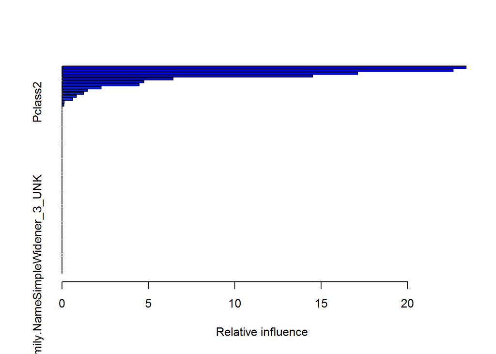

```
## Confusion Matrix and Statistics
##
##           Reference
## Prediction perished survived
##   perished      105       14
##   survived        9       50
##
##                Accuracy : 0.8708
##                  95% CI : (0.8124, 0.9163)
##     No Information Rate : 0.6404
##     P-Value [Acc > NIR] : 4.163e-12
##
##                   Kappa : 0.7145
##  Mcnemar's Test P-Value : 0.4042
##
##             Sensitivity : 0.7812
##             Specificity : 0.9211
##          Pos Pred Value : 0.8475
##          Neg Pred Value : 0.8824
##              Prevalence : 0.3596
##          Detection Rate : 0.2809
##    Detection Prevalence : 0.3315
##       Balanced Accuracy : 0.8512
##
##        'Positive' Class : survived
##
##
## Call:
## roc.default(response = as.numeric(pred), predictor = as.numeric(data$Fate),     auc = T)
##
## Data: as.numeric(data$Fate) in 119 controls (as.numeric(pred) 1) < 59 cases (as.numeric(pred) 2).
## Area under the curve: 0.8649
```

```r
tune.grid.gbm <- expand.grid(shrinkage = 0.06319474, n.trees = c(150,200), interaction.depth = c(5, 6, 7), n.minobsinnode = c(1, 5))
train.gbm.best <- train(Fate ~ Sex + Pclass + Fare.PerPerson + Family.Size + Title + Age + Ticket.Count + Embarked + Deck, train.batch, method = "gbm", metric = "ROC", trControl = trc.recv, tuneGrid = tune.grid.gbm)
```

show model summary

```r
results.gbm.best <- model.summary(train.gbm.best)
```

```
## SUMMARY
```

```
##                           var    rel.inf
## Fare.PerPerson Fare.PerPerson 22.8609954
## TitleMr               TitleMr 21.2070034
## Age                       Age 18.4833290
## Sexmale               Sexmale  8.3610056
## Pclass3               Pclass3  4.9255876
## Family.Size       Family.Size  4.9171375
## Ticket.Count     Ticket.Count  4.6528209
## TitleNoble         TitleNoble  3.3247302
## DeckUNK               DeckUNK  1.9829229
## DeckE                   DeckE  1.9639134
## EmbarkedS           EmbarkedS  1.4460278
## DeckC                   DeckC  1.0936284
## DeckD                   DeckD  0.9566030
## TitleMrs             TitleMrs  0.9103965
## TitleMiss           TitleMiss  0.8620740
## Pclass2               Pclass2  0.6648273
## EmbarkedQ           EmbarkedQ  0.6435221
## DeckF                   DeckF  0.4893689
## DeckB                   DeckB  0.2541060
```

```
## VARIMP
```

```
## gbm variable importance
##
##                Overall
## Fare.PerPerson 100.000
## TitleMr         92.684
## Age             80.636
## Sexmale         35.860
## Pclass3         20.664
## Family.Size     20.627
## Ticket.Count    19.457
## TitleNoble      13.583
## DeckUNK          7.647
## DeckE            7.563
## EmbarkedS        5.272
## DeckC            3.714
## DeckD            3.107
## TitleMrs         2.903
## TitleMiss        2.689
## Pclass2          1.817
## EmbarkedQ        1.723
## DeckF            1.041
## DeckB            0.000
```

```
## Confusion Matrix
```

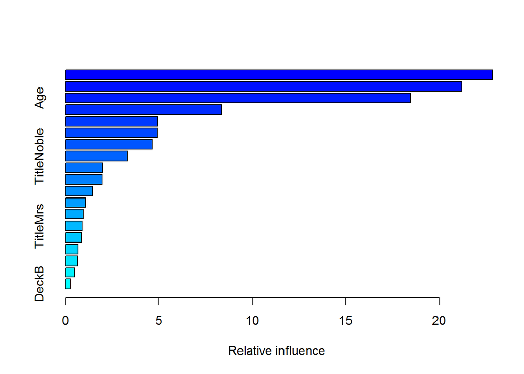

```
## Confusion Matrix and Statistics
##
##           Reference
## Prediction perished survived
##   perished      103        9
##   survived       11       55
##
##                Accuracy : 0.8876
##                  95% CI : (0.8318, 0.93)
##     No Information Rate : 0.6404
##     P-Value [Acc > NIR] : 6.149e-14
##
##                   Kappa : 0.7577
##  Mcnemar's Test P-Value : 0.8231
##
##             Sensitivity : 0.8594
##             Specificity : 0.9035
##          Pos Pred Value : 0.8333
##          Neg Pred Value : 0.9196
##              Prevalence : 0.3596
##          Detection Rate : 0.3090
##    Detection Prevalence : 0.3708
##       Balanced Accuracy : 0.8814
##
##        'Positive' Class : survived
##
##
## Call:
## roc.default(response = as.numeric(pred), predictor = as.numeric(data$Fate),     auc = T)
##
## Data: as.numeric(data$Fate) in 112 controls (as.numeric(pred) 1) < 66 cases (as.numeric(pred) 2).
## Area under the curve: 0.8765
```

```r
tune.grid.gbm <- expand.grid(shrinkage = 0.06319474, n.trees = c(150), interaction.depth = c(5,7,9), n.minobsinnode = c(1))
train.gbm <- train(Fate ~ Sex + Pclass + Fare.PerPerson + Family.Size + Title + Age + Ticket.Count + Embarked + Deck, train.batch, method = "gbm", metric = "ROC", trControl = trc.recv, tuneGrid = tune.grid.gbm)
```

show model summary

```r
results.gbm <- model.summary(train.gbm)
```

```
## SUMMARY
```

```
##                           var    rel.inf
## Fare.PerPerson Fare.PerPerson 22.3795939
## TitleMr               TitleMr 17.8740459
## Age                       Age 17.3598961
## Sexmale               Sexmale 13.3378472
## Ticket.Count     Ticket.Count  6.3929301
## Pclass3               Pclass3  5.6139922
## Family.Size       Family.Size  4.5510411
## TitleNoble         TitleNoble  2.7341527
## DeckE                   DeckE  2.5212177
## TitleMrs             TitleMrs  1.2446237
## DeckD                   DeckD  1.2347799
## DeckUNK               DeckUNK  1.1642666
## EmbarkedS           EmbarkedS  1.1238201
## EmbarkedQ           EmbarkedQ  0.6478790
## DeckC                   DeckC  0.5856829
## TitleMiss           TitleMiss  0.4746651
## DeckB                   DeckB  0.3466969
## DeckF                   DeckF  0.2260712
## Pclass2               Pclass2  0.1867976
```

```
## VARIMP
```

```
## gbm variable importance
##
##                 Overall
## Fare.PerPerson 100.0000
## TitleMr         79.6982
## Age             77.3814
## Sexmale         59.2582
## Ticket.Count    27.9646
## Pclass3         24.4548
## Family.Size     19.6651
## TitleNoble      11.4783
## DeckE           10.5188
## TitleMrs         4.7665
## DeckD            4.7222
## DeckUNK          4.4044
## EmbarkedS        4.2222
## EmbarkedQ        2.0776
## DeckC            1.7974
## TitleMiss        1.2971
## DeckB            0.7205
## DeckF            0.1770
## Pclass2          0.0000
```

```
## Confusion Matrix
```

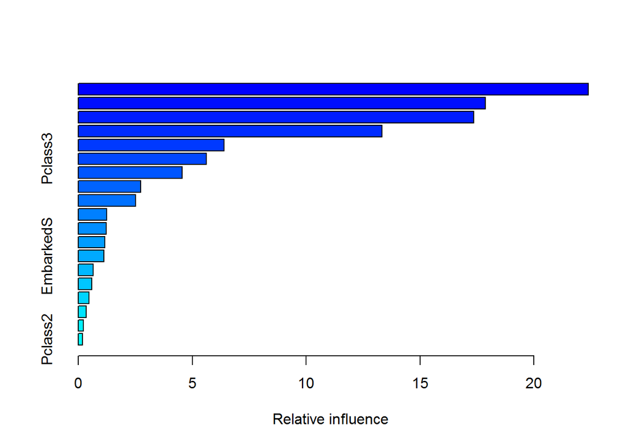

```
## Confusion Matrix and Statistics
##
##           Reference
## Prediction perished survived
##   perished      102       14
##   survived       12       50
##
##                Accuracy : 0.8539
##                  95% CI : (0.7933, 0.9023)
##     No Information Rate : 0.6404
##     P-Value [Acc > NIR] : 1.82e-10
##
##                   Kappa : 0.6807
##  Mcnemar's Test P-Value : 0.8445
##
##             Sensitivity : 0.7812
##             Specificity : 0.8947
##          Pos Pred Value : 0.8065
##          Neg Pred Value : 0.8793
##              Prevalence : 0.3596
##          Detection Rate : 0.2809
##    Detection Prevalence : 0.3483
##       Balanced Accuracy : 0.8380
##
##        'Positive' Class : survived
##
##
## Call:
## roc.default(response = as.numeric(pred), predictor = as.numeric(data$Fate),     auc = T)
##
## Data: as.numeric(data$Fate) in 116 controls (as.numeric(pred) 1) < 62 cases (as.numeric(pred) 2).
## Area under the curve: 0.8429
```

### Performance summary

**GLM**

[output not shown]

**KNN**

| formula | bad | accuracy | AUC | preProcess |
| --- | --- | --- | --- | --- |
| **`Fate ~ Sex + Pclass + Fare.PerPerson + Family.Size + Title + Age + Family.NameSimple`** | 29 | 0.8371 | 0.8319 |  |

**RF**

[output not shown]

**CFOREST**

| formula | bad | accuracy | AUC | preProcess |
| --- | --- | --- | --- | --- |
| `Fate ~ Sex + Pclass + Fare.PerPerson + Family.Size + Title + Age + Ticket.Count + Ticket.Name` | 25 | 0.8596 | 0.8522 |  |

**C5.0**

| formula | bad | accuracy | AUC | preProcess |
| --- | --- | --- | --- | --- |
| `Fate ~ Sex + Pclass + Fare.PerPerson + Family.Size + Title + Age + Ticket.Count + Ticket.Name` | 29 | 0.8371 | 0.8269 |  |
| **`Fate ~ Sex + Pclass + Fare.PerPerson + Family.Size + Title + Age + Ticket.Count + Family.NameSimple`** | 25 | 0.8596 | 0.8469 |  |
| `Fate ~ Sex + Pclass + Fare.PerPerson + Family.Size + Title + Age + Ticket.Count + Family.NameSimple + Embarked` | 28 | 0.8427 | 0.8322 |  |
| `Fate ~ Sex + Pclass + Fare.PerPerson + Family.Size + Title + Age + Ticket.Count + Family.NameSimple + Embarked` | 25 | 0.8596 | 0.8469 |  |
| `Fate ~ Sex + Pclass + Fare.PerPerson + Family.Size + Title + Age + Ticket.Count + Family.NameSimple + Embarked` | 25 | 0.8596 | 0.8469 |  |

**Stochastic Gradient Boosting**

| formula | bad | accuracy | AUC | preProcess |
| --- | --- | --- | --- | --- |
| `Fate ~ Sex + Pclass + Fare.PerPerson + Family.Size + Title + Age + Ticket.Count + Family.NameSimple + Embarked` | 23 | 0.8708 | 0.8649 |  |
| **`Fate ~ Sex + Pclass + Fare.PerPerson + Family.Size + Title + Age + Ticket.Count + Embarked + Deck`** | 20 | 0.8876 | 0.8765 | shrinkage = 0.06319474, n.trees = c(150,200), interaction.depth = c(5, 6, 7), n.minobsinnode = c(1, 5) |
| `Fate ~ Sex + Pclass + Fare.PerPerson + Family.Size + Title + Age + Ticket.Count + Embarked + Deck` | 26 | 0.8539 | 0.8429 | shrinkage = 0.06319474, n.trees = c(150), interaction.depth = c(5,7,9), n.minobsinnode = c(1) |

#### Wrong predictions summary

```r
rows.test <- function(pred, data = test.batch) {
    return(which(!(data$Fate == pred)))
}
```

**GLM**

```r
rows.bad <- rows.test(results.glm)
# Wrong predicted table
kable (test.batch[rows.bad,c("PassengerId","Pclass","Age","Sex","Title","Fare.PerPerson","Survived","Ticket.Name","Family.Size","Ticket.Count","Age.IsMother")] %>% arrange (Pclass, Survived),
       col.names=c("Id", "Class", "Age", "Sex", "Title", "Fare", "Survived", "Ticket", "FamSize", "TicketCount", "IsMother"))
```

| Id | Class | Age | Sex | Title | Fare | Survived | Ticket | FamSize | TicketCount | IsMother |
| --- | --- | --- | --- | --- | --- | --- | --- | --- | --- | --- |
| 98 | 1 | 23.0 | male | Mr | 31.679150 | 1 | PP1 | 2 | 2 | FALSE |
| 225 | 1 | 38.0 | male | Mr | 45.000000 | 1 | UNK | 2 | 2 | FALSE |
| 588 | 1 | 60.0 | male | Mr | 26.400000 | 1 | UNK | 3 | 2 | FALSE |
| 633 | 1 | 32.0 | male | Noble | 30.500000 | 1 | UNK | 1 | 1 | FALSE |
| 682 | 1 | 27.0 | male | Mr | 76.729200 | 1 | PP1 | 1 | 3 | FALSE |
| 708 | 1 | 42.0 | male | Mr | 26.287500 | 1 | PP1 | 1 | 1 | FALSE |
| 858 | 1 | 51.0 | male | Mr | 26.550000 | 1 | UNK | 1 | 1 | FALSE |
| 890 | 1 | 26.0 | male | Mr | 30.000000 | 1 | UNK | 1 | 1 | FALSE |
| 18 | 2 | 24.0 | male | Mr | 13.000000 | 1 | UNK | 1 | 1 | FALSE |
| 112 | 3 | 14.5 | female | Miss | 7.227100 | 0 | UNK | 2 | 2 | FALSE |
| 115 | 3 | 17.0 | female | Miss | 14.458300 | 0 | UNK | 1 | 2 | FALSE |
| 177 | 3 | 2.0 | male | Master | 5.093340 | 0 | UNK | 5 | 5 | FALSE |
| 405 | 3 | 20.0 | female | Miss | 8.662500 | 0 | UNK | 1 | 1 | FALSE |
| 502 | 3 | 21.0 | female | Miss | 7.750000 | 0 | UNK | 1 | 1 | FALSE |
| 535 | 3 | 30.0 | female | Miss | 8.662500 | 0 | UNK | 1 | 1 | FALSE |
| 565 | 3 | 15.0 | female | Miss | 8.050000 | 0 | SO3 | 1 | 1 | FALSE |
| 730 | 3 | 25.0 | female | Miss | 3.962500 | 0 | ST3 | 2 | 1 | FALSE |
| 808 | 3 | 18.0 | female | Miss | 7.775000 | 0 | UNK | 1 | 1 | FALSE |
| 208 | 3 | 26.0 | male | Mr | 18.787500 | 1 | UNK | 1 | 2 | FALSE |
| 302 | 3 | 25.0 | male | Mr | 7.750000 | 1 | UNK | 3 | 3 | FALSE |
| 329 | 3 | 31.0 | female | Mrs | 6.841667 | 1 | UNK | 3 | 3 | TRUE |
| 392 | 3 | 21.0 | male | Mr | 7.795800 | 1 | UNK | 1 | 1 | FALSE |
| 623 | 3 | 20.0 | male | Mr | 5.247233 | 1 | UNK | 3 | 3 | FALSE |
| 644 | 3 | 48.0 | male | Mr | 56.495800 | 1 | UNK | 1 | 8 | FALSE |
| 859 | 3 | 24.0 | female | Mrs | 4.814575 | 1 | UNK | 4 | 4 | TRUE |

```r
print(table(test.batch$Pclass[rows.bad], test.batch$Survived[rows.bad]))
```

```
##
##     0 1
##   1 0 8
##   2 0 1
##   3 9 7
```

**RF**

```r
rows.bad <- rows.test(results.rf.best)
# Wrong predicted table
kable (test.batch[rows.bad,c("PassengerId","Pclass","Age","Sex","Title","Fare.PerPerson","Survived","Ticket.Name","Family.Size","Ticket.Count","Age.IsMother")] %>% arrange (Pclass, Survived),
       col.names=c("Id", "Class", "Age", "Sex", "Title", "Fare", "Survived", "Ticket", "FamSize", "TicketCount", "IsMother"))
```

| Id | Class | Age | Sex | Title | Fare | Survived | Ticket | FamSize | TicketCount | IsMother |
| --- | --- | --- | --- | --- | --- | --- | --- | --- | --- | --- |
| 749 | 1 | 19.0 | male | Mr | 26.550000 | 0 | UNK | 2 | 2 | FALSE |
| 98 | 1 | 23.0 | male | Mr | 31.679150 | 1 | PP1 | 2 | 2 | FALSE |
| 225 | 1 | 38.0 | male | Mr | 45.000000 | 1 | UNK | 2 | 2 | FALSE |
| 588 | 1 | 60.0 | male | Mr | 26.400000 | 1 | UNK | 3 | 2 | FALSE |
| 633 | 1 | 32.0 | male | Noble | 30.500000 | 1 | UNK | 1 | 1 | FALSE |
| 682 | 1 | 27.0 | male | Mr | 76.729200 | 1 | PP1 | 1 | 3 | FALSE |
| 738 | 1 | 35.0 | male | Mr | 512.329200 | 1 | PP1 | 1 | 4 | FALSE |
| 858 | 1 | 51.0 | male | Mr | 26.550000 | 1 | UNK | 1 | 1 | FALSE |
| 18 | 2 | 24.0 | male | Mr | 13.000000 | 1 | UNK | 1 | 1 | FALSE |
| 112 | 3 | 14.5 | female | Miss | 7.227100 | 0 | UNK | 2 | 2 | FALSE |
| 115 | 3 | 17.0 | female | Miss | 14.458300 | 0 | UNK | 1 | 2 | FALSE |
| 405 | 3 | 20.0 | female | Miss | 8.662500 | 0 | UNK | 1 | 1 | FALSE |
| 424 | 3 | 28.0 | female | Mrs | 4.800000 | 0 | UNK | 3 | 3 | TRUE |
| 502 | 3 | 21.0 | female | Miss | 7.750000 | 0 | UNK | 1 | 1 | FALSE |
| 565 | 3 | 15.0 | female | Miss | 8.050000 | 0 | SO3 | 1 | 1 | FALSE |
| 594 | 3 | 17.0 | female | Miss | 2.583333 | 0 | UNK | 3 | 1 | FALSE |
| 730 | 3 | 25.0 | female | Miss | 3.962500 | 0 | ST3 | 2 | 1 | FALSE |
| 808 | 3 | 18.0 | female | Miss | 7.775000 | 0 | UNK | 1 | 1 | FALSE |
| 853 | 3 | 9.0 | female | Miss | 5.081933 | 0 | UNK | 3 | 3 | FALSE |
| 208 | 3 | 26.0 | male | Mr | 18.787500 | 1 | UNK | 1 | 2 | FALSE |
| 302 | 3 | 25.0 | male | Mr | 7.750000 | 1 | UNK | 3 | 3 | FALSE |
| 392 | 3 | 21.0 | male | Mr | 7.795800 | 1 | UNK | 1 | 1 | FALSE |
| 623 | 3 | 20.0 | male | Mr | 5.247233 | 1 | UNK | 3 | 3 | FALSE |

```r
print(table(test.batch$Pclass[rows.bad], test.batch$Survived[rows.bad]))
```

```
##
##      0  1
##   1  1  7
##   2  0  1
##   3 10  4
```

**C5.0**

```r
rows.bad <- rows.test(results.c5.best)
# Wrong predicted table
kable (test.batch[rows.bad,c("PassengerId","Pclass","Age","Sex","Title","Fare.PerPerson","Survived","Ticket.Name","Family.Size","Ticket.Count","Age.IsMother")] %>% arrange (Pclass, Survived),
       col.names=c("Id", "Class", "Age", "Sex", "Title", "Fare", "Survived", "Ticket", "FamSize", "TicketCount", "IsMother"))
```

| Id | Class | Age | Sex | Title | Fare | Survived | Ticket | FamSize | TicketCount | IsMother |
| --- | --- | --- | --- | --- | --- | --- | --- | --- | --- | --- |
| 97 | 1 | 71.0 | male | Mr | 34.654200 | 0 | PP1 | 1 | 1 | FALSE |
| 749 | 1 | 19.0 | male | Mr | 26.550000 | 0 | UNK | 2 | 2 | FALSE |
| 98 | 1 | 23.0 | male | Mr | 31.679150 | 1 | PP1 | 2 | 2 | FALSE |
| 225 | 1 | 38.0 | male | Mr | 45.000000 | 1 | UNK | 2 | 2 | FALSE |
| 588 | 1 | 60.0 | male | Mr | 26.400000 | 1 | UNK | 3 | 2 | FALSE |
| 633 | 1 | 32.0 | male | Noble | 30.500000 | 1 | UNK | 1 | 1 | FALSE |
| 682 | 1 | 27.0 | male | Mr | 76.729200 | 1 | PP1 | 1 | 3 | FALSE |
| 738 | 1 | 35.0 | male | Mr | 512.329200 | 1 | PP1 | 1 | 4 | FALSE |
| 858 | 1 | 51.0 | male | Mr | 26.550000 | 1 | UNK | 1 | 1 | FALSE |
| 18 | 2 | 24.0 | male | Mr | 13.000000 | 1 | UNK | 1 | 1 | FALSE |
| 112 | 3 | 14.5 | female | Miss | 7.227100 | 0 | UNK | 2 | 2 | FALSE |
| 115 | 3 | 17.0 | female | Miss | 14.458300 | 0 | UNK | 1 | 2 | FALSE |
| 405 | 3 | 20.0 | female | Miss | 8.662500 | 0 | UNK | 1 | 1 | FALSE |
| 424 | 3 | 28.0 | female | Mrs | 4.800000 | 0 | UNK | 3 | 3 | TRUE |
| 502 | 3 | 21.0 | female | Miss | 7.750000 | 0 | UNK | 1 | 1 | FALSE |
| 565 | 3 | 15.0 | female | Miss | 8.050000 | 0 | SO3 | 1 | 1 | FALSE |
| 594 | 3 | 17.0 | female | Miss | 2.583333 | 0 | UNK | 3 | 1 | FALSE |
| 730 | 3 | 25.0 | female | Miss | 3.962500 | 0 | ST3 | 2 | 1 | FALSE |
| 808 | 3 | 18.0 | female | Miss | 7.775000 | 0 | UNK | 1 | 1 | FALSE |
| 827 | 3 | 23.0 | male | Mr | 56.495800 | 0 | UNK | 1 | 8 | FALSE |
| 853 | 3 | 9.0 | female | Miss | 5.081933 | 0 | UNK | 3 | 3 | FALSE |
| 208 | 3 | 26.0 | male | Mr | 18.787500 | 1 | UNK | 1 | 2 | FALSE |
| 302 | 3 | 25.0 | male | Mr | 7.750000 | 1 | UNK | 3 | 3 | FALSE |
| 392 | 3 | 21.0 | male | Mr | 7.795800 | 1 | UNK | 1 | 1 | FALSE |
| 623 | 3 | 20.0 | male | Mr | 5.247233 | 1 | UNK | 3 | 3 | FALSE |

```r
print(table(test.batch$Pclass[rows.bad], test.batch$Survived[rows.bad]))
```

```
##
##      0  1
##   1  2  7
##   2  0  1
##   3 11  4
```

**Stochastic Gradient Boosting**

```r
rows.bad <- rows.test(results.gbm.best)
# Wrong predicted table
kable (test.batch[rows.bad,c("PassengerId","Pclass","Age","Sex","Title","Fare.PerPerson","Survived","Ticket.Name","Family.Size","Ticket.Count","Age.IsMother")] %>% arrange (Pclass, Survived),
       col.names=c("Id", "Class", "Age", "Sex", "Title", "Fare", "Survived", "Ticket", "FamSize", "TicketCount", "IsMother"))
```

| Id | Class | Age | Sex | Title | Fare | Survived | Ticket | FamSize | TicketCount | IsMother |
| --- | --- | --- | --- | --- | --- | --- | --- | --- | --- | --- |
| 749 | 1 | 19.0 | male | Mr | 26.550000 | 0 | UNK | 2 | 2 | FALSE |
| 225 | 1 | 38.0 | male | Mr | 45.000000 | 1 | UNK | 2 | 2 | FALSE |
| 588 | 1 | 60.0 | male | Mr | 26.400000 | 1 | UNK | 3 | 2 | FALSE |
| 858 | 1 | 51.0 | male | Mr | 26.550000 | 1 | UNK | 1 | 1 | FALSE |
| 18 | 2 | 24.0 | male | Mr | 13.000000 | 1 | UNK | 1 | 1 | FALSE |
| 775 | 2 | 54.0 | female | Mrs | 4.600000 | 1 | UNK | 5 | 2 | TRUE |
| 112 | 3 | 14.5 | female | Miss | 7.227100 | 0 | UNK | 2 | 2 | FALSE |
| 115 | 3 | 17.0 | female | Miss | 14.458300 | 0 | UNK | 1 | 2 | FALSE |
| 424 | 3 | 28.0 | female | Mrs | 4.800000 | 0 | UNK | 3 | 3 | TRUE |
| 443 | 3 | 25.0 | male | Mr | 3.887500 | 0 | UNK | 2 | 1 | FALSE |
| 502 | 3 | 21.0 | female | Miss | 7.750000 | 0 | UNK | 1 | 1 | FALSE |
| 565 | 3 | 15.0 | female | Miss | 8.050000 | 0 | SO3 | 1 | 1 | FALSE |
| 594 | 3 | 17.0 | female | Miss | 2.583333 | 0 | UNK | 3 | 1 | FALSE |
| 730 | 3 | 25.0 | female | Miss | 3.962500 | 0 | ST3 | 2 | 1 | FALSE |
| 808 | 3 | 18.0 | female | Miss | 7.775000 | 0 | UNK | 1 | 1 | FALSE |
| 853 | 3 | 9.0 | female | Miss | 5.081933 | 0 | UNK | 3 | 3 | FALSE |
| 208 | 3 | 26.0 | male | Mr | 18.787500 | 1 | UNK | 1 | 2 | FALSE |
| 302 | 3 | 25.0 | male | Mr | 7.750000 | 1 | UNK | 3 | 3 | FALSE |
| 392 | 3 | 21.0 | male | Mr | 7.795800 | 1 | UNK | 1 | 1 | FALSE |
| 623 | 3 | 20.0 | male | Mr | 5.247233 | 1 | UNK | 3 | 3 | FALSE |

```r
print(table(test.batch$Pclass[rows.bad], test.batch$Survived[rows.bad]))
```

```
##
##      0  1
##   1  1  3
##   2  0  2
##   3 10  4
```

## Ensemble

### Caret

```r
suppressMessages(library(caretEnsemble))
```

```r
trc.ens <- trainControl(method = "repeatedcv", repeats = 10, p = 0.8, summaryFunction = twoClassSummary, savePredictions = "final", classProbs = TRUE, returnResamp = "final", returnData = TRUE, verboseIter = TRUE, allowParallel = TRUE)
suppressMessages(mod.ens <- caretList(Fate ~ Sex + Pclass + Fare.PerPerson + Family.Size + Title + Age + Ticket.Count + Family.NameSimple + Embarked + Side, data = train.batch, trControl = trc.ens, methodList = c("C5.0", "rf", "knn", "gbm"), metric = "ROC"))
summary(mod.ens)
modelCor(resamples(mod.ens))
car.ens <- caretEnsemble(mod.ens, metric="ROC", trControl = trainControl(number=2, summaryFunction=twoClassSummary, classProbs=T))
```

```r
pred.ens <- predict(car.ens, test.batch,type="raw")
confusionMatrix(pred.ens, test.batch$Fate, positive="survived")
#stack.ens <- caretStack(mod.ens, method = "glm", trControl = trc.ens, metric="ROC")
#stack.ens
```

#### stack2

```r
trc.ens <- trainControl(method = "cv", repeats = 1, number = 10, p = 0.8, summaryFunction = twoClassSummary, savePredictions = "final", classProbs = TRUE, returnResamp = "final", returnData = TRUE, verboseIter = TRUE, allowParallel = TRUE)
suppressMessages(mod.ens <- caretList(Fate ~ Sex + Pclass + Fare.PerPerson + Family.Size + Title + Age + Ticket.Count + Family.NameSimple + Embarked + Side, data = train.batch, trControl = trc.ens, methodList = c("C5.0", "rf", "knn", "gbm"), metric = "ROC"))
summary(mod.ens)
modelCor(resamples(mod.ens))
car.ens <- caretEnsemble(mod.ens, metric="ROC", trControl = trainControl(number=2, summaryFunction=twoClassSummary, classProbs=T))
```

```r
pred.ens <- predict(car.ens, test.batch,type="raw")
confusionMatrix(pred.ens, test.batch$Fate, positive="survived")
```

#### stack3

```r
nn <- suppressMessages(mod.ens <- caretList(Fate ~ Sex + Pclass + Fare.PerPerson + Family.Size + Title + Age + Ticket.Count + Family.NameSimple + Embarked + Side, data = train.batch, trControl = trc.ens, methodList = c("rf", "knn", "svmRadial", "cforest","rf","glmnet"), metric = "ROC"))
modelCor(resamples(mod.ens))
car.ens <- caretEnsemble(mod.ens, metric="ROC", trControl = trainControl(number=2, summaryFunction=twoClassSummary, classProbs=T))
```

```r
pred.ens <- predict(car.ens, test.batch,type="raw")
confusionMatrix(pred.ens, test.batch$Fate, positive="survived")
```

#### stack4

```r
tuneList <- list (
    #knn=caretModelSpec(method="knn", tuneLength=1),
    knn=caretModelSpec(method="knn", tuneLength=5, preProcess=c("center","scale","nzv")),
    C5.0=caretModelSpec(method="C5.0", tuneLength=5),
    cforest=caretModelSpec(method="cforest", tuneLength=5),
    rf=caretModelSpec(method="rf", tuneLength=5),
    svmRadial=caretModelSpec(method="svmRadial",tuneLength=5),
    glmnet=caretModelSpec(method="glmnet",tuneLength=5)
)
nn <- suppressMessages(mod.ens <- caretList(Fate ~ Sex + Pclass + Fare.PerPerson + Family.Size + Title + Age + Ticket.Count + Family.NameSimple + Embarked + Side, data = train.batch, trControl = trc.ens, tuneList=tuneList, metric = "ROC"))
modelCor(resamples(mod.ens))
car.ens <- caretEnsemble(mod.ens, metric="ROC", trControl = trainControl(number=2, summaryFunction=twoClassSummary, classProbs=T))
```

```r
summary(car.ens)
pred.ens <- predict(car.ens, test.batch,type="raw")
confusionMatrix(pred.ens, test.batch$Fate, positive="survived")
```

```r
pred.ens <- predict(car.ens, test.pre,type="raw")
pred.ens.inv <- as.integer(!as.integer(pred.ens)-1)
result <- data.frame(Survived=pred.ens.inv, PassengerId=test.pre$PassengerId)
write.csv(result, "titanic.csv", quote=F, row.names=F)
```

### GLM in Pclass partitions

We will split the datasets in two batches: one with passengers for 1st and 2nd class, and the other for the rest of passengers

```r
model.split.by.pclass <- function (data.train, data.test, procCM = T) {
    rows.train.pclass3 <- data.train$Pclass == 3
    rows.test.pclass3 <- data.test$Pclass == 3
    train.tune.pclass3 <- train(Fate ~ Sex + Fare.PerPerson + Family.Size + Title + Age, data = data.train, method = "glm", metric = "ROC", trControl = trc.recv, preProcess="nzv")
    pred.class3 <- predict(train.tune.pclass3, data.test[rows.test.pclass3,])
    results.class3 <- data.frame(Fate=pred.class3, PassengerId = data.test$PassengerId[rows.test.pclass3])
    train.tune.pclass12 <- train(Fate ~ Sex + Pclass + Fare.PerPerson + Sex:Pclass + Family.Size + Title + Age, data = data.train, method = "glm", metric = "ROC", trControl = trc.recv, preProcess="nzv")
    pred.class12 <- predict(train.tune.pclass12, data.test[!rows.test.pclass3,])
    results.class12 <- data.frame(Fate=pred.class12, PassengerId = data.test$PassengerId[!rows.test.pclass3])
    results <- results.class3 %>% bind_rows(results.class12) %>% arrange(PassengerId)
    if (procCM)
    {
        message("Confusion Matrix")
        print (confusionMatrix(results$Fate, (data.test %>% arrange(PassengerId))[["Fate"]], positive="survived"))
        rows.bad <- which(!(results$Fate == (data.test %>% arrange(PassengerId))[["Fate"]]))
        message("Bad predictions rows")
        print (data.test[rows.bad,c("Pclass","Age","Sex","Title","Fare","Survived","Ticket","Family.Size","Ticket.Count","Age.IsMother")] %>% arrange(Pclass, Survived), n=22)
        print(table(data.test$Pclass[rows.bad],data.test$Survived[rows.bad]))
    }
    return (data.frame(Survived=as.numeric(results$Fate) - 1, PassengerId = results$PassengerId))
}
```

```r
result <- model.split.by.pclass (train.batch, test.batch)
```

```
## Confusion Matrix
```

```
## Confusion Matrix and Statistics
##
##           Reference
## Prediction perished survived
##   perished      103       14
##   survived       11       50
##
##                Accuracy : 0.8596
##                  95% CI : (0.7997, 0.907)
##     No Information Rate : 0.6404
##     P-Value [Acc > NIR] : 5.408e-11
##
##                   Kappa : 0.6919
##  Mcnemar's Test P-Value : 0.6892
##
##             Sensitivity : 0.7812
##             Specificity : 0.9035
##          Pos Pred Value : 0.8197
##          Neg Pred Value : 0.8803
##              Prevalence : 0.3596
##          Detection Rate : 0.2809
##    Detection Prevalence : 0.3427
##       Balanced Accuracy : 0.8424
##
##        'Positive' Class : survived
##
```

```
## Bad predictions rows
```

```
## Source: local data frame [25 x 10]
##
##    Pclass   Age    Sex  Title    Fare Survived            Ticket Family.Size Ticket.Count Age.IsMother
##    (fctr) (dbl) (fctr) (fctr)   (dbl)    (int)             (chr)       (dbl)        (dbl)        (lgl)
## 1       1  23.0   male     Mr 63.3583        1          PC 17759           2            2        FALSE
## 2       1  38.0   male     Mr 90.0000        1             19943           2            2        FALSE
## 3       1  60.0   male     Mr 79.2000        1             13567           3            2        FALSE
## 4       1  27.0   male     Mr 76.7292        1          PC 17572           1            3        FALSE
## 5       1  42.0   male     Mr 26.2875        1          PC 17476           1            1        FALSE
## 6       1  51.0   male     Mr 26.5500        1            113055           1            1        FALSE
## 7       1  26.0   male     Mr 30.0000        1            111369           1            1        FALSE
## 8       2  24.0   male     Mr 13.0000        1            244373           1            1        FALSE
## 9       2   1.0   male Master 39.0000        1            230136           4            4        FALSE
## 10      3  14.5 female   Miss 14.4542        0              2665           2            2        FALSE
## 11      3  17.0 female   Miss 14.4583        0              2627           1            2        FALSE
```

[output cut: 17 more lines]

```r
model.split.by.pclass_rf <- function (data.train, data.test, procCM = T) {
    rows.train.pclass3 <- data.train$Pclass == 3
    rows.test.pclass3 <- data.test$Pclass == 3
    train.tune.pclass3 <- train(Fate ~ Sex + Fare.PerPerson + Family.Size + Title + Age, data = data.train, method = "glm", metric = "ROC", trControl = trc.recv, preProcess="nzv")
    pred.class3 <- predict(train.tune.pclass3, data.test[rows.test.pclass3,])
    results.class3 <- data.frame(Fate=pred.class3, PassengerId = data.test$PassengerId[rows.test.pclass3])
    train.tune.pclass12 <- train(Fate ~ Sex + Pclass + Fare.PerPerson + Family.Size + Title + Age + Ticket.Count + Ticket.Name, data.train, method = "rf", metric = "ROC", trControl = trc.recv, tuneLength=5)
    pred.class12 <- predict(train.tune.pclass12, data.test[!rows.test.pclass3,])
    results.class12 <- data.frame(Fate=pred.class12, PassengerId = data.test$PassengerId[!rows.test.pclass3])
    results <- results.class3 %>% bind_rows(results.class12) %>% arrange(PassengerId)
    if (procCM)
    {
        message("Confusion Matrix")
        print (confusionMatrix(results$Fate, (data.test %>% arrange(PassengerId))[["Fate"]], positive="survived"))
        rows.bad <- which(!(results$Fate == (data.test %>% arrange(PassengerId))[["Fate"]]))
        message("Bad predictions rows")
        print (data.test[rows.bad,c("Pclass","Age","Sex","Title","Fare.PerPerson","Survived","Ticket","Family.Size","Ticket.Count","Age.IsMother")] %>% arrange(Pclass, Survived), n=22)
        print(table(data.test$Pclass[rows.bad],data.test$Survived[rows.bad]))
    }
    return (data.frame(Survived=as.numeric(results$Fate) - 1, PassengerId = results$PassengerId))
}
```

```r
result <- model.split.by.pclass_rf (train.batch, test.batch)
```

[output not shown]

Kaggle submission score: 0.79904

```r
result <- model.split.by.pclass_rf (train.pre, test.pre, F)
```

```r
model.split.by.pclass_rf <- function (data.train, data.test, procCM = T) {
    rows.train.pclass3 <- data.train$Pclass == 3
    rows.test.pclass3 <- data.test$Pclass == 3
    train.tune.pclass3 <- train(Fate ~ Sex + Pclass + Fare.PerPerson + Family.Size + Title + Age + Ticket.Count + Family.NameSimple + Embarked, data.train, method = "C5.0", metric = "ROC", trControl = trc.recv, tuneLength=5)
    pred.class3 <- predict(train.tune.pclass3, data.test[rows.test.pclass3,])
    results.class3 <- data.frame(Fate=pred.class3, PassengerId = data.test$PassengerId[rows.test.pclass3])
    train.tune.pclass12 <- train(Fate ~ Sex + Pclass + Fare.PerPerson + Family.Size + Title + Age + Ticket.Count + Ticket.Name, data.train, method = "rf", metric = "ROC", trControl = trc.recv, tuneLength=5)
    pred.class12 <- predict(train.tune.pclass12, data.test[!rows.test.pclass3,])
    results.class12 <- data.frame(Fate=pred.class12, PassengerId = data.test$PassengerId[!rows.test.pclass3])
    results <- results.class3 %>% bind_rows(results.class12) %>% arrange(PassengerId)
    if (procCM)
    {
        message("Confusion Matrix")
        print (confusionMatrix(results$Fate, (data.test %>% arrange(PassengerId))[["Fate"]], positive="survived"))
        rows.bad <- which(!(results$Fate == (data.test %>% arrange(PassengerId))[["Fate"]]))
        message("Bad predictions rows")
        print (data.test[rows.bad,c("Pclass","Age","Sex","Title","Fare.PerPerson","Survived","Ticket","Family.Size","Ticket.Count","Age.IsMother")] %>% arrange(Pclass, Survived), n=22)
        print(table(data.test$Pclass[rows.bad],data.test$Survived[rows.bad]))
    }
    return (data.frame(Survived=as.numeric(results$Fate) - 1, PassengerId = results$PassengerId))
}
```

```r
result <- model.split.by.pclass_rf (train.batch, test.batch)
```

```
## Confusion Matrix
```

```
## Confusion Matrix and Statistics
##
##           Reference
## Prediction perished survived
##   perished      102       16
##   survived       12       48
##
##                Accuracy : 0.8427
##                  95% CI : (0.7807, 0.8929)
##     No Information Rate : 0.6404
##     P-Value [Acc > NIR] : 1.81e-09
##
##                   Kappa : 0.6537
##  Mcnemar's Test P-Value : 0.5708
##
##             Sensitivity : 0.7500
##             Specificity : 0.8947
##          Pos Pred Value : 0.8000
##          Neg Pred Value : 0.8644
##              Prevalence : 0.3596
##          Detection Rate : 0.2697
##    Detection Prevalence : 0.3371
##       Balanced Accuracy : 0.8224
##
##        'Positive' Class : survived
##
```

```
## Bad predictions rows
```

```
## Source: local data frame [28 x 10]
##
##    Pclass   Age    Sex  Title Fare.PerPerson Survived            Ticket Family.Size Ticket.Count Age.IsMother
##    (fctr) (dbl) (fctr) (fctr)          (dbl)    (int)             (chr)       (dbl)        (dbl)        (lgl)
## 1       1  19.0   male     Mr      26.550000        0            113773           2            2        FALSE
## 2       1  23.0   male     Mr      31.679150        1          PC 17759           2            2        FALSE
## 3       1  38.0   male     Mr      45.000000        1             19943           2            2        FALSE
## 4       1  60.0   male     Mr      26.400000        1             13567           3            2        FALSE
## 5       1  32.0   male  Noble      30.500000        1             13214           1            1        FALSE
## 6       1  27.0   male     Mr      76.729200        1          PC 17572           1            3        FALSE
## 7       1  35.0   male     Mr     512.329200        1          PC 17755           1            4        FALSE
## 8       1  51.0   male     Mr      26.550000        1            113055           1            1        FALSE
## 9       2  24.0   male     Mr      13.000000        1            244373           1            1        FALSE
## 10      3  14.5 female   Miss       7.227100        0              2665           2            2        FALSE
## 11      3  17.0 female   Miss      14.458300        0              2627           1            2        FALSE
```

[output cut: 17 more lines]

```r
model.split.by.pclass_gbm <- function (data.train, data.test, procCM = T) {
    rows.train.pclass3 <- data.train$Pclass == 3
    rows.test.pclass3 <- data.test$Pclass == 3
    train.tune.pclass3 <- train(Fate ~ Sex + Pclass + Fare.PerPerson + Family.Size + Title + Age + Ticket.Count + Family.NameSimple + Embarked, data.train, method = "C5.0", metric = "ROC", trControl = trc.recv, tuneLength=5)
    pred.class3 <- predict(train.tune.pclass3, data.test[rows.test.pclass3,])
    results.class3 <- data.frame(Fate=pred.class3, PassengerId = data.test$PassengerId[rows.test.pclass3])
    tune.grid.gbm <- expand.grid(shrinkage = 0.06319474, n.trees = c(150), interaction.depth = c(5,7,9), n.minobsinnode = c(1))
    train.tune.pclass12 <- train(Fate ~ Sex + Pclass + Fare.PerPerson + Family.Size + Title + Age + Ticket.Count + Embarked + Deck, data.train, method = "gbm", metric = "ROC", trControl = trc.recv, tuneGrid = tune.grid.gbm)
    pred.class12 <- predict(train.tune.pclass12, data.test[!rows.test.pclass3,])
    results.class12 <- data.frame(Fate=pred.class12, PassengerId = data.test$PassengerId[!rows.test.pclass3])
    results <- results.class3 %>% bind_rows(results.class12) %>% arrange(PassengerId)
    if (procCM)
    {
        message("Confusion Matrix")
        print (confusionMatrix(results$Fate, (data.test %>% arrange(PassengerId))[["Fate"]], positive="survived"))
        rows.bad <- which(!(results$Fate == (data.test %>% arrange(PassengerId))[["Fate"]]))
        message("Bad predictions rows")
        print (data.test[rows.bad,c("Pclass","Age","Sex","Title","Fare.PerPerson","Survived","Ticket","Family.Size","Ticket.Count","Age.IsMother")] %>% arrange(Pclass, Survived), n=22)
        print(table(data.test$Pclass[rows.bad],data.test$Survived[rows.bad]))
    }
    return (data.frame(Survived=as.numeric(results$Fate) - 1, PassengerId = results$PassengerId))
}
```

```r
result <- model.split.by.pclass_gbm (train.batch, test.batch, F)
#write.csv(result, "titanic.csv", quote=F, row.names=F)
```

## Notes

Saves markdown workspace

```r
#save.image(file="titanic.rmd.RData")
```

Special cases: passengers with the same ticket, but no location.

```r
tickets.any.cabin <- unlist (combi %>% filter (!is.na(Cabin)) %>% select (Ticket) %>% distinct())
combi %>% filter (is.na(Cabin) & Ticket %in% tickets.any.cabin) %>% select (Pclass,Ticket, Cabin, Side, Side.Prob)
```

C62 & C64 -> ?? B24 - B73/B69 -> not related, there were change at the last time (http://www.encyclopedia-titanica.org/titanic-survivor/mary-anne-perreault.html)

> She was moved from her originally allocated room of B-73 so Mr Hay’s could have closer access to his secretary Mr. Vivian Ponsonby Payne

B57 B59 B63 B66 -> B66 was opposite side B57

Check offending cases:

```r
combi %>% filter(Ticket == "110413") %>% select(Name, Age, Fare, Ticket, Pclass, Cabin)
```

[output not shown]

E,F -> first and second class -> port side E -> third class -> startboard

Information from [Passenger of the RMS Titanic](https://en.wikipedia.org/wiki/Passengers_of_the_RMS_Titanic) and [Titanic Facts and Figures](http://www.keyflux.com/titanic/facts.htm)

| Class | Cost | Observations |
| --- | --- | --- |
| 1st | 870 | parlor suite |
| 1st | 30 | berth |
| 2nd | 12 |  |
| 3rd | 3-8 | depending origin city |
| 3rd (children) | 3 |  |

Family tickets were also available to make it more affordable to large families.

The term “steerage” derives from the location of the 3rd class passengers, down with the “steering” apparatus in the bowels of the ship

PAR (ARRIBA): odd for cabins on the starboard side IMPAR (ABAJO): even for the port side

A,B,C,D,F,G DECK: convention

E DECK: 1st/2nd: port side 3rd: both sides

First Class suites, berths, and social rooms were located mainly at the center of the ship on decks A, B, and C, with additional cabins on decks D and E. Second Class rooms were mostly located on decks D and E, with some on lower decks F and G. Steerage passengers had rooms on lower decks F and G, with some exceptions

First, we start reviewing deck plans, and check following deck / class passenger distribution

| Deck | Class | Side |
| --- | --- | --- |
| E | 1st | portside |
| E | 2nd | portside |
| E | 3rd | startboard side |
| F | 1st | portside |
| F | 2nd | portside |

*REVIEW: data does not comply former table*